# Project: Wrangling and Analyze Data

**Project Overview**

Real-world data rarely comes clean. Using Python and its libraries, you will gather data from a variety of sources and in a variety of formats, assess its quality and tidiness, then clean it. This is called data wrangling. You will document your wrangling efforts in a Jupyter Notebook, plus showcase them through analyses and visualizations using Python (and its libraries) and/or SQL.

The dataset that you will be wrangling (and analyzing and visualizing) is the tweet archive of Twitter user @dog_rates, also known as WeRateDogs. WeRateDogs is a Twitter account that rates people's dogs with a humorous comment about the dog. These ratings almost always have a denominator of 10. The numerators, though? Almost always greater than 10. 11/10, 12/10, 13/10, etc. Why? Because "they're good dogs Brent." WeRateDogs has over 4 million followers and has received international media coverage.

- Section#1: Data Gathering
- Section#2: Assessing Data
- Section#3: Cleaning Data
- Section#4: Storing Data
- Section#5: Analyzing and visualizing

## Data Gathering

In the cell below, gather **all** three pieces of data for this project and load them in the notebook. **Note:** the methods required to gather each data are different.

1. Directly download the WeRateDogs Twitter archive data (twitter_archive_enhanced.csv)

```python
#import packges
import numpy as np
import pandas as pd
```

```python
#read csv file to dataframe
archive_df = pd.read_csv('twitter-archive-enhanced.csv')
archive_df.head()
```

|  | tweet_id | in_reply_to_status_id | in_reply_to_user_id | timestamp | source | text | retweeted_status_id | retweeted_status_user_id | retweeted_status_timestamp | expanded_urls | rating_numerator | rating_denominator | name | doggo | floofer | pupper | puppo |
| --- | --- | --- | --- | --- | --- | --- | --- | --- | --- | --- | --- | --- | --- | --- | --- | --- | --- |
| 0 | 892420643555336193 | NaN | NaN | 2017-08-01 16:23:56 +0000 | <a href="http://twitter.com/download/iphone" r... | This is Phineas. He's a mystical boy. Only eve... | NaN | NaN | NaN | https://twitter.com/dog_rates/status/892420643... | 13 | 10 | Phineas | None | None | None | None |
| 1 | 892177421306343426 | NaN | NaN | 2017-08-01 00:17:27 +0000 | <a href="http://twitter.com/download/iphone" r... | This is Tilly. She's just checking pup on you.... | NaN | NaN | NaN | https://twitter.com/dog_rates/status/892177421... | 13 | 10 | Tilly | None | None | None | None |
| 2 | 891815181378084864 | NaN | NaN | 2017-07-31 00:18:03 +0000 | <a href="http://twitter.com/download/iphone" r... | This is Archie. He is a rare Norwegian Pouncin... | NaN | NaN | NaN | https://twitter.com/dog_rates/status/891815181... | 12 | 10 | Archie | None | None | None | None |
| 3 | 891689557279858688 | NaN | NaN | 2017-07-30 15:58:51 +0000 | <a href="http://twitter.com/download/iphone" r... | This is Darla. She commenced a snooze mid meal... | NaN | NaN | NaN | https://twitter.com/dog_rates/status/891689557... | 13 | 10 | Darla | None | None | None | None |
| 4 | 891327558926688256 | NaN | NaN | 2017-07-29 16:00:24 +0000 | <a href="http://twitter.com/download/iphone" r... | This is Franklin. He would like you to stop ca... | NaN | NaN | NaN | https://twitter.com/dog_rates/status/891327558... | 12 | 10 | Franklin | None | None | None | None |

1. Use the Requests library to download the tweet image prediction (image_predictions.tsv)

```python
import requests
url = 'https://d17h27t6h515a5.cloudfront.net/topher/2017/August/599fd2ad_image-predictions/image-predictions.tsv'
response = requests.get(url)

# Save HTML to file

with open("image_predictions.tsv", mode='wb') as file:
    file.write(response.content)
```

```python
#content of image_prediction.tsv
images_df = pd.read_csv('image_predictions.tsv', sep = '\t')
images_df.head(3)
```

|  | tweet_id | jpg_url | img_num | p1 | p1_conf | p1_dog | p2 | p2_conf | p2_dog | p3 | p3_conf | p3_dog |
| --- | --- | --- | --- | --- | --- | --- | --- | --- | --- | --- | --- | --- |
| 0 | 666020888022790149 | https://pbs.twimg.com/media/CT4udn0WwAA0aMy.jpg | 1 | Welsh_springer_spaniel | 0.465074 | True | collie | 0.156665 | True | Shetland_sheepdog | 0.061428 | True |
| 1 | 666029285002620928 | https://pbs.twimg.com/media/CT42GRgUYAA5iDo.jpg | 1 | redbone | 0.506826 | True | miniature_pinscher | 0.074192 | True | Rhodesian_ridgeback | 0.072010 | True |
| 2 | 666033412701032449 | https://pbs.twimg.com/media/CT4521TWwAEvMyu.jpg | 1 | German_shepherd | 0.596461 | True | malinois | 0.138584 | True | bloodhound | 0.116197 | True |

```python
import tweepy
from tweepy import OAuthHandler
import json
from timeit import default_timer as timer

# Query Twitter API for each tweet in the Twitter archive and save JSON in a text file
# These are hidden to comply with Twitter's API terms and conditions
consumer_key = 'HIDDEN'
consumer_secret = 'HIDDEN'
access_token = 'HIDDEN'
access_secret = 'HIDDEN'

auth = OAuthHandler(consumer_key, consumer_secret)
auth.set_access_token(access_token, access_secret)

api = tweepy.API(auth, wait_on_rate_limit=True)

# NOTE TO STUDENT WITH MOBILE VERIFICATION ISSUES:
# df_1 is a DataFrame with the twitter_archive_enhanced.csv file. You may have to
# change line 17 to match the name of your DataFrame with twitter_archive_enhanced.csv
# NOTE TO REVIEWER: this student had mobile verification issues so the following
# Twitter API code was sent to this student from a Udacity instructor
# Tweet IDs for which to gather additional data via Twitter's API
tweet_ids = archive_df.tweet_id.values
len(tweet_ids)

# Query Twitter's API for JSON data for each tweet ID in the Twitter archive
count = 0
fails_dict = {}
start = timer()
# Save each tweet's returned JSON as a new line in a .txt file
with open('tweet_json.txt', 'w') as outfile:
    # This loop will likely take 20-30 minutes to run because of Twitter's rate limit
    for tweet_id in tweet_ids:
        count += 1
       # print(str(count) + ": " + str(tweet_id))
        try:
            tweet = api.get_status(tweet_id, tweet_mode='extended')
         #   print("Success")
            json.dump(tweet._json, outfile)
            outfile.write('\n')
        except tweepy.TweepError as e:
         #   print("Fail")
            fails_dict[tweet_id] = e
            pass
end = timer()
#print(end - start)
#print(fails_dict)
```

1. Use the Tweepy library to query additional data via the Twitter API (tweet_json.txt)

```python
#query data from tweet_json.txt file
contents = []
with open("tweet-json.txt") as file:
    for line in file:
        line_value = json.loads(line)
        contents.append(line_value)

df_tweet_temp = pd.DataFrame(contents)
df_tweet_extra = df_tweet_temp[['id', 'retweet_count','favorite_count']].copy()
```

```python
df_tweet_extra
```

|  | id | retweet_count | favorite_count |
| --- | --- | --- | --- |
| 0 | 892420643555336193 | 8853 | 39467 |
| 1 | 892177421306343426 | 6514 | 33819 |
| 2 | 891815181378084864 | 4328 | 25461 |
| 3 | 891689557279858688 | 8964 | 42908 |
| 4 | 891327558926688256 | 9774 | 41048 |
| 5 | 891087950875897856 | 3261 | 20562 |
| 6 | 890971913173991426 | 2158 | 12041 |
| 7 | 890729181411237888 | 16716 | 56848 |
| 8 | 890609185150312448 | 4429 | 28226 |
| 9 | 890240255349198849 | 7711 | 32467 |
| 10 | 890006608113172480 | 7624 | 31166 |
| 11 | 889880896479866881 | 5156 | 28268 |
| 12 | 889665388333682689 | 8538 | 38818 |
| 13 | 889638837579907072 | 4735 | 27672 |
| 14 | 889531135344209921 | 2321 | 15359 |
| 15 | 889278841981685760 | 5637 | 25652 |
| 16 | 888917238123831296 | 4709 | 29611 |
| 17 | 888804989199671297 | 4559 | 26080 |
| 18 | 888554962724278272 | 3732 | 20290 |
| 19 | 888078434458587136 | 3653 | 22201 |
| 20 | 887705289381826560 | 5609 | 30779 |
| 21 | 887517139158093824 | 12082 | 46959 |
| 22 | 887473957103951883 | 18781 | 69871 |
| 23 | 887343217045368832 | 10737 | 34222 |
| 24 | 887101392804085760 | 6167 | 31061 |
| 25 | 886983233522544640 | 8084 | 35859 |
| 26 | 886736880519319552 | 3443 | 12306 |
| 27 | 886680336477933568 | 4610 | 22798 |
| 28 | 886366144734445568 | 3316 | 21524 |
| 29 | 886267009285017600 | 4 | 117 |
| ... | ... | ... | ... |
| 2324 | 666411507551481857 | 339 | 459 |
| 2325 | 666407126856765440 | 44 | 113 |
| 2326 | 666396247373291520 | 92 | 172 |
| 2327 | 666373753744588802 | 100 | 194 |
| 2328 | 666362758909284353 | 595 | 804 |
| 2329 | 666353288456101888 | 77 | 229 |
| 2330 | 666345417576210432 | 146 | 307 |
| 2331 | 666337882303524864 | 96 | 204 |
| 2332 | 666293911632134144 | 368 | 522 |
| 2333 | 666287406224695296 | 71 | 152 |
| 2334 | 666273097616637952 | 82 | 184 |
| 2335 | 666268910803644416 | 37 | 108 |
| 2336 | 666104133288665088 | 6871 | 14765 |
| 2337 | 666102155909144576 | 16 | 81 |
| 2338 | 666099513787052032 | 73 | 164 |
| 2339 | 666094000022159362 | 79 | 169 |
| 2340 | 666082916733198337 | 47 | 121 |
| 2341 | 666073100786774016 | 174 | 335 |
| 2342 | 666071193221509120 | 67 | 154 |
| 2343 | 666063827256086533 | 232 | 496 |
| 2344 | 666058600524156928 | 61 | 115 |
| 2345 | 666057090499244032 | 146 | 304 |
| 2346 | 666055525042405380 | 261 | 448 |
| 2347 | 666051853826850816 | 879 | 1253 |
| 2348 | 666050758794694657 | 60 | 136 |
| 2349 | 666049248165822465 | 41 | 111 |
| 2350 | 666044226329800704 | 147 | 311 |
| 2351 | 666033412701032449 | 47 | 128 |
| 2352 | 666029285002620928 | 48 | 132 |
| 2353 | 666020888022790149 | 532 | 2535 |

2354 rows × 3 columns

## Assessing Data

In this section, detect and document at least **eight (8) quality issues and two (2) tidiness issue**. You must use **both** visual assessment programmatic assessement to assess the data.

```python
#sample of df
##Return a random sample of items from an axis of object.
archive_df.sample(7)
```

|  | tweet_id | in_reply_to_status_id | in_reply_to_user_id | timestamp | source | text | retweeted_status_id | retweeted_status_user_id | retweeted_status_timestamp | expanded_urls | rating_numerator | rating_denominator | name | doggo | floofer | pupper | puppo |
| --- | --- | --- | --- | --- | --- | --- | --- | --- | --- | --- | --- | --- | --- | --- | --- | --- | --- |
| 936 | 753375668877008896 | NaN | NaN | 2016-07-13 23:48:51 +0000 | <a href="http://twitter.com/download/iphone" r... | This is Hank. He's mischievous af. Doesn't eve... | NaN | NaN | NaN | https://twitter.com/dog_rates/status/753375668... | 8 | 10 | Hank | None | None | None | None |
| 463 | 817423860136083457 | NaN | NaN | 2017-01-06 17:33:29 +0000 | <a href="http://twitter.com/download/iphone" r... | This is Ken. His cheeks are magic. 13/10 (IG: ... | NaN | NaN | NaN | https://twitter.com/dog_rates/status/817423860... | 13 | 10 | Ken | None | None | None | None |
| 161 | 860563773140209665 | NaN | NaN | 2017-05-05 18:36:06 +0000 | <a href="http://twitter.com/download/iphone" r... | Meet Lorenzo. He's an avid nifty hat wearer an... | NaN | NaN | NaN | https://www.gofundme.com/help-lorenzo-beat-can... | 13 | 10 | Lorenzo | None | None | None | None |
| 1142 | 727524757080539137 | NaN | NaN | 2016-05-03 15:46:33 +0000 | <a href="http://twitter.com/download/iphone" r... | This pupper had to undergo emergency haircut s... | NaN | NaN | NaN | https://twitter.com/dog_rates/status/727524757... | 10 | 10 | None | None | None | pupper | None |
| 374 | 828372645993398273 | NaN | NaN | 2017-02-05 22:40:03 +0000 | <a href="http://twitter.com/download/iphone" r... | This is Alexander Hamilpup. He was one of the ... | NaN | NaN | NaN | https://twitter.com/dog_rates/status/828372645... | 12 | 10 | Alexander | None | None | None | None |
| 2118 | 670420569653809152 | NaN | NaN | 2015-11-28 01:54:54 +0000 | <a href="http://twitter.com/download/iphone" r... | This is Damon. The newest presidential candida... | NaN | NaN | NaN | https://twitter.com/dog_rates/status/670420569... | 10 | 10 | Damon | None | None | None | None |
| 1660 | 683078886620553216 | NaN | NaN | 2016-01-02 00:14:32 +0000 | <a href="http://twitter.com/download/iphone" r... | Here we see a nifty leaping pupper. Feet look ... | NaN | NaN | NaN | https://twitter.com/dog_rates/status/683078886... | 9 | 10 | None | None | None | pupper | None |

```python
#Print a concise summary of a DataFrame.
archive_df.info()
```

```
<class 'pandas.core.frame.DataFrame'>
RangeIndex: 2356 entries, 0 to 2355
Data columns (total 17 columns):
tweet_id                      2356 non-null int64
in_reply_to_status_id         78 non-null float64
in_reply_to_user_id           78 non-null float64
timestamp                     2356 non-null object
source                        2356 non-null object
text                          2356 non-null object
retweeted_status_id           181 non-null float64
retweeted_status_user_id      181 non-null float64
retweeted_status_timestamp    181 non-null object
expanded_urls                 2297 non-null object
rating_numerator              2356 non-null int64
rating_denominator            2356 non-null int64
name                          2356 non-null object
doggo                         2356 non-null object
floofer                       2356 non-null object
pupper                        2356 non-null object
puppo                         2356 non-null object
dtypes: float64(4), int64(3), object(10)
memory usage: 313.0+ KB
```

```python
#Return a Series containing counts of unique values of rating numerator
archive_df.rating_numerator.value_counts()
```

```
12      558
11      464
10      461
13      351
9       158
8       102
7        55
14       54
5        37
6        32
3        19
4        17
1         9
2         9
420       2
```

[output cut: 26 more lines]

```python
#Return a Series containing counts of unique values of rating_denominator
archive_df.rating_denominator.value_counts()
```

```
10     2333
11        3
50        3
80        2
20        2
2         1
16        1
40        1
70        1
15        1
90        1
110       1
120       1
130       1
150       1
170       1
7         1
0         1
Name: rating_denominator, dtype: int64
```

```python
#all rows of rating_denominator larger than 10
archive_df[archive_df.rating_denominator >10]
```

|  | tweet_id | in_reply_to_status_id | in_reply_to_user_id | timestamp | source | text | retweeted_status_id | retweeted_status_user_id | retweeted_status_timestamp | expanded_urls | rating_numerator | rating_denominator | name | doggo | floofer | pupper | puppo |
| --- | --- | --- | --- | --- | --- | --- | --- | --- | --- | --- | --- | --- | --- | --- | --- | --- | --- |
| 342 | 832088576586297345 | 8.320875e+17 | 3.058208e+07 | 2017-02-16 04:45:50 +0000 | <a href="http://twitter.com/download/iphone" r... | @docmisterio account started on 11/15/15 | NaN | NaN | NaN | NaN | 11 | 15 | None | None | None | None | None |
| 433 | 820690176645140481 | NaN | NaN | 2017-01-15 17:52:40 +0000 | <a href="http://twitter.com/download/iphone" r... | The floofs have been released I repeat the flo... | NaN | NaN | NaN | https://twitter.com/dog_rates/status/820690176... | 84 | 70 | None | None | None | None | None |
| 784 | 775096608509886464 | NaN | NaN | 2016-09-11 22:20:06 +0000 | <a href="http://twitter.com/download/iphone" r... | RT @dog_rates: After so many requests, this is... | 7.403732e+17 | 4.196984e+09 | 2016-06-08 02:41:38 +0000 | https://twitter.com/dog_rates/status/740373189... | 9 | 11 | None | None | None | None | None |
| 902 | 758467244762497024 | NaN | NaN | 2016-07-28 01:00:57 +0000 | <a href="http://twitter.com/download/iphone" r... | Why does this never happen at my front door...... | NaN | NaN | NaN | https://twitter.com/dog_rates/status/758467244... | 165 | 150 | None | None | None | None | None |
| 1068 | 740373189193256964 | NaN | NaN | 2016-06-08 02:41:38 +0000 | <a href="http://twitter.com/download/iphone" r... | After so many requests, this is Bretagne. She ... | NaN | NaN | NaN | https://twitter.com/dog_rates/status/740373189... | 9 | 11 | None | None | None | None | None |
| 1120 | 731156023742988288 | NaN | NaN | 2016-05-13 16:15:54 +0000 | <a href="http://twitter.com/download/iphone" r... | Say hello to this unbelievably well behaved sq... | NaN | NaN | NaN | https://twitter.com/dog_rates/status/731156023... | 204 | 170 | this | None | None | None | None |
| 1165 | 722974582966214656 | NaN | NaN | 2016-04-21 02:25:47 +0000 | <a href="http://twitter.com/download/iphone" r... | Happy 4/20 from the squad! 13/10 for all https... | NaN | NaN | NaN | https://twitter.com/dog_rates/status/722974582... | 4 | 20 | None | None | None | None | None |
| 1202 | 716439118184652801 | NaN | NaN | 2016-04-03 01:36:11 +0000 | <a href="http://twitter.com/download/iphone" r... | This is Bluebert. He just saw that both #Final... | NaN | NaN | NaN | https://twitter.com/dog_rates/status/716439118... | 50 | 50 | Bluebert | None | None | None | None |
| 1228 | 713900603437621249 | NaN | NaN | 2016-03-27 01:29:02 +0000 | <a href="http://twitter.com/download/iphone" r... | Happy Saturday here's 9 puppers on a bench. 99... | NaN | NaN | NaN | https://twitter.com/dog_rates/status/713900603... | 99 | 90 | None | None | None | None | None |
| 1254 | 710658690886586372 | NaN | NaN | 2016-03-18 02:46:49 +0000 | <a href="http://twitter.com/download/iphone" r... | Here's a brigade of puppers. All look very pre... | NaN | NaN | NaN | https://twitter.com/dog_rates/status/710658690... | 80 | 80 | None | None | None | None | None |
| 1274 | 709198395643068416 | NaN | NaN | 2016-03-14 02:04:08 +0000 | <a href="http://twitter.com/download/iphone" r... | From left to right:\nCletus, Jerome, Alejandro... | NaN | NaN | NaN | https://twitter.com/dog_rates/status/709198395... | 45 | 50 | None | None | None | None | None |
| 1351 | 704054845121142784 | NaN | NaN | 2016-02-28 21:25:30 +0000 | <a href="http://twitter.com/download/iphone" r... | Here is a whole flock of puppers. 60/50 I'll ... | NaN | NaN | NaN | https://twitter.com/dog_rates/status/704054845... | 60 | 50 | a | None | None | None | None |
| 1433 | 697463031882764288 | NaN | NaN | 2016-02-10 16:51:59 +0000 | <a href="http://twitter.com/download/iphone" r... | Happy Wednesday here's a bucket of pups. 44/40... | NaN | NaN | NaN | https://twitter.com/dog_rates/status/697463031... | 44 | 40 | None | None | None | None | None |
| 1598 | 686035780142297088 | 6.860340e+17 | 4.196984e+09 | 2016-01-10 04:04:10 +0000 | <a href="http://twitter.com/download/iphone" r... | Yes I do realize a rating of 4/20 would've bee... | NaN | NaN | NaN | NaN | 4 | 20 | None | None | None | None | None |
| 1634 | 684225744407494656 | 6.842229e+17 | 4.196984e+09 | 2016-01-05 04:11:44 +0000 | <a href="http://twitter.com/download/iphone" r... | Two sneaky puppers were not initially seen, mo... | NaN | NaN | NaN | https://twitter.com/dog_rates/status/684225744... | 143 | 130 | None | None | None | None | None |
| 1635 | 684222868335505415 | NaN | NaN | 2016-01-05 04:00:18 +0000 | <a href="http://twitter.com/download/iphone" r... | Someone help the girl is being mugged. Several... | NaN | NaN | NaN | https://twitter.com/dog_rates/status/684222868... | 121 | 110 | None | None | None | None | None |
| 1662 | 682962037429899265 | NaN | NaN | 2016-01-01 16:30:13 +0000 | <a href="http://twitter.com/download/iphone" r... | This is Darrel. He just robbed a 7/11 and is i... | NaN | NaN | NaN | https://twitter.com/dog_rates/status/682962037... | 7 | 11 | Darrel | None | None | None | None |
| 1663 | 682808988178739200 | 6.827884e+17 | 4.196984e+09 | 2016-01-01 06:22:03 +0000 | <a href="http://twitter.com/download/iphone" r... | I'm aware that I could've said 20/16, but here... | NaN | NaN | NaN | NaN | 20 | 16 | None | None | None | None | None |
| 1779 | 677716515794329600 | NaN | NaN | 2015-12-18 05:06:23 +0000 | <a href="http://twitter.com/download/iphone" r... | IT'S PUPPERGEDDON. Total of 144/120 ...I think... | NaN | NaN | NaN | https://twitter.com/dog_rates/status/677716515... | 144 | 120 | None | None | None | None | None |
| 1843 | 675853064436391936 | NaN | NaN | 2015-12-13 01:41:41 +0000 | <a href="http://twitter.com/download/iphone" r... | Here we have an entire platoon of puppers. Tot... | NaN | NaN | NaN | https://twitter.com/dog_rates/status/675853064... | 88 | 80 | None | None | None | None | None |

```python
#Compute the length of each element in the Series of rating denominator that larger than 10.
len(archive_df[archive_df.rating_denominator >10])
```

```
20
```

```python
#Compute the length of each element in the Series of rating_numerator that larger than 20.
len(archive_df[archive_df.rating_numerator >20])
```

```
24
```

```python
#check duplicated tweet id
sum(archive_df.tweet_id.duplicated())
```

```
0
```

```python
archive_df.name.value_counts()
```

```
None           745
a               55
Charlie         12
Cooper          11
Oliver          11
Lucy            11
Penny           10
Tucker          10
Lola            10
Winston          9
Bo               9
Sadie            8
the              8
Daisy            7
Bailey           7
an               7
Toby             7
Buddy            7
Oscar            6
Milo             6
Bella            6
Leo              6
Dave             6
Stanley          6
Jack             6
Jax              6
Scout            6
Koda             6
Rusty            6
Bentley          5
              ...
Christoper       1
Jaycob           1
all              1
Patch            1
Lambeau          1
Jimbo            1
Vinnie           1
Mark             1
Evy              1
Chuq             1
Jazz             1
Luther           1
Lugan            1
Dallas           1
infuriating      1
Zeek             1
Butters          1
Billy            1
Teddy            1
Brooks           1
Donny            1
Carll            1
Lucia            1
Scruffers        1
Lenox            1
Claude           1
Link             1
Wiggles          1
Enchilada        1
Ambrose          1
Name: name, Length: 957, dtype: int64
```

```python
#show only 20 top names and their corresponding counts
archive_df.name.value_counts()[:20]
```

```
None       745
a           55
Charlie     12
Cooper      11
Oliver      11
Lucy        11
Penny       10
Tucker      10
Lola        10
Winston      9
Bo           9
Sadie        8
the          8
Daisy        7
Bailey       7
an           7
Toby         7
Buddy        7
Oscar        6
Milo         6
Name: name, dtype: int64
```

```python
#plot of names and their corresponding value counts
archive_df.name.value_counts()[:20].plot(kind='barh')
```

[output not shown]

```python
#dictionary of dog stages and corresponding value counts of each stage
dog_stages = {
  "doggo": archive_df.doggo.value_counts()[1],
  "floofer": archive_df.floofer.value_counts()[1],
  "pupper": archive_df.pupper.value_counts()[1],
  "puppo": archive_df.puppo.value_counts()[1]
}
dog_stages
```

```
{'doggo': 97, 'floofer': 10, 'pupper': 257, 'puppo': 30}
```

```python
#descriptive statistics.
archive_df.describe()
```

|  | tweet_id | in_reply_to_status_id | in_reply_to_user_id | retweeted_status_id | retweeted_status_user_id | rating_numerator | rating_denominator |
| --- | --- | --- | --- | --- | --- | --- | --- |
| count | 2.356000e+03 | 7.800000e+01 | 7.800000e+01 | 1.810000e+02 | 1.810000e+02 | 2356.000000 | 2356.000000 |
| mean | 7.427716e+17 | 7.455079e+17 | 2.014171e+16 | 7.720400e+17 | 1.241698e+16 | 13.126486 | 10.455433 |
| std | 6.856705e+16 | 7.582492e+16 | 1.252797e+17 | 6.236928e+16 | 9.599254e+16 | 45.876648 | 6.745237 |
| min | 6.660209e+17 | 6.658147e+17 | 1.185634e+07 | 6.661041e+17 | 7.832140e+05 | 0.000000 | 0.000000 |
| 25% | 6.783989e+17 | 6.757419e+17 | 3.086374e+08 | 7.186315e+17 | 4.196984e+09 | 10.000000 | 10.000000 |
| 50% | 7.196279e+17 | 7.038708e+17 | 4.196984e+09 | 7.804657e+17 | 4.196984e+09 | 11.000000 | 10.000000 |
| 75% | 7.993373e+17 | 8.257804e+17 | 4.196984e+09 | 8.203146e+17 | 4.196984e+09 | 12.000000 | 10.000000 |
| max | 8.924206e+17 | 8.862664e+17 | 8.405479e+17 | 8.874740e+17 | 7.874618e+17 | 1776.000000 | 170.000000 |

```python
images_df.head(3)
```

|  | tweet_id | jpg_url | img_num | p1 | p1_conf | p1_dog | p2 | p2_conf | p2_dog | p3 | p3_conf | p3_dog |
| --- | --- | --- | --- | --- | --- | --- | --- | --- | --- | --- | --- | --- |
| 0 | 666020888022790149 | https://pbs.twimg.com/media/CT4udn0WwAA0aMy.jpg | 1 | Welsh_springer_spaniel | 0.465074 | True | collie | 0.156665 | True | Shetland_sheepdog | 0.061428 | True |
| 1 | 666029285002620928 | https://pbs.twimg.com/media/CT42GRgUYAA5iDo.jpg | 1 | redbone | 0.506826 | True | miniature_pinscher | 0.074192 | True | Rhodesian_ridgeback | 0.072010 | True |
| 2 | 666033412701032449 | https://pbs.twimg.com/media/CT4521TWwAEvMyu.jpg | 1 | German_shepherd | 0.596461 | True | malinois | 0.138584 | True | bloodhound | 0.116197 | True |

```python
# general information of images dataframe
images_df.info()
```

```
<class 'pandas.core.frame.DataFrame'>
RangeIndex: 2075 entries, 0 to 2074
Data columns (total 12 columns):
tweet_id    2075 non-null int64
jpg_url     2075 non-null object
img_num     2075 non-null int64
p1          2075 non-null object
p1_conf     2075 non-null float64
p1_dog      2075 non-null bool
p2          2075 non-null object
p2_conf     2075 non-null float64
p2_dog      2075 non-null bool
p3          2075 non-null object
p3_conf     2075 non-null float64
p3_dog      2075 non-null bool
dtypes: bool(3), float64(3), int64(2), object(4)
memory usage: 152.1+ KB
```

```python
#Return the last n rows.
images_df.tail()
```

|  | tweet_id | jpg_url | img_num | p1 | p1_conf | p1_dog | p2 | p2_conf | p2_dog | p3 | p3_conf | p3_dog |
| --- | --- | --- | --- | --- | --- | --- | --- | --- | --- | --- | --- | --- |
| 2070 | 891327558926688256 | https://pbs.twimg.com/media/DF6hr6BUMAAzZgT.jpg | 2 | basset | 0.555712 | True | English_springer | 0.225770 | True | German_short-haired_pointer | 0.175219 | True |
| 2071 | 891689557279858688 | https://pbs.twimg.com/media/DF_q7IAWsAEuuN8.jpg | 1 | paper_towel | 0.170278 | False | Labrador_retriever | 0.168086 | True | spatula | 0.040836 | False |
| 2072 | 891815181378084864 | https://pbs.twimg.com/media/DGBdLU1WsAANxJ9.jpg | 1 | Chihuahua | 0.716012 | True | malamute | 0.078253 | True | kelpie | 0.031379 | True |
| 2073 | 892177421306343426 | https://pbs.twimg.com/media/DGGmoV4XsAAUL6n.jpg | 1 | Chihuahua | 0.323581 | True | Pekinese | 0.090647 | True | papillon | 0.068957 | True |
| 2074 | 892420643555336193 | https://pbs.twimg.com/media/DGKD1-bXoAAIAUK.jpg | 1 | orange | 0.097049 | False | bagel | 0.085851 | False | banana | 0.076110 | False |

```python
#check duplicates in tweet id of images_df
sum(images_df.tweet_id.duplicated())
```

```
0
```

```python
#check duplicates in jpg url of images_df
sum(images_df.jpg_url.duplicated())
```

```
66
```

```python
# p1 predictions and their value counts
images_df.p1.value_counts()
```

```
golden_retriever             150
Labrador_retriever           100
Pembroke                      89
Chihuahua                     83
pug                           57
chow                          44
Samoyed                       43
toy_poodle                    39
Pomeranian                    38
malamute                      30
cocker_spaniel                30
French_bulldog                26
miniature_pinscher            23
Chesapeake_Bay_retriever      23
seat_belt                     22
German_shepherd               20
Siberian_husky                20
Staffordshire_bullterrier     20
Cardigan                      19
web_site                      19
teddy                         18
beagle                        18
Eskimo_dog                    18
Maltese_dog                   18
Shetland_sheepdog             18
Lakeland_terrier              17
Rottweiler                    17
Shih-Tzu                      17
Italian_greyhound             16
kuvasz                        16
                            ...
water_buffalo                  1
EntleBucher                    1
canoe                          1
bakery                         1
bookshop                       1
black-footed_ferret            1
military_uniform               1
syringe                        1
cheeseburger                   1
skunk                          1
espresso                       1
swab                           1
tiger_shark                    1
piggy_bank                     1
radio_telescope                1
crane                          1
coho                           1
polecat                        1
mortarboard                    1
cougar                         1
revolver                       1
maze                           1
electric_fan                   1
grey_fox                       1
remote_control                 1
rain_barrel                    1
leopard                        1
sandbar                        1
starfish                       1
microphone                     1
Name: p1, Length: 378, dtype: int64
```

```python
# p2 predictions and their value counts
images_df.p2.value_counts()
```

```
Labrador_retriever                104
golden_retriever                   92
Cardigan                           73
Chihuahua                          44
Pomeranian                         42
Chesapeake_Bay_retriever           41
French_bulldog                     41
toy_poodle                         37
cocker_spaniel                     34
Siberian_husky                     33
miniature_poodle                   33
beagle                             28
collie                             27
Eskimo_dog                         27
Pembroke                           27
kuvasz                             26
Italian_greyhound                  22
American_Staffordshire_terrier     21
Pekinese                           21
malinois                           20
chow                               20
Samoyed                            20
miniature_pinscher                 20
toy_terrier                        20
Norwegian_elkhound                 19
Boston_bull                        19
Staffordshire_bullterrier          18
Irish_terrier                      17
pug                                17
Shih-Tzu                           16
                                 ...
canoe                               1
otter                               1
junco                               1
sandbar                             1
torch                               1
turnstile                           1
cornet                              1
bow                                 1
lesser_panda                        1
comic_book                          1
triceratops                         1
grey_fox                            1
screw                               1
spotted_salamander                  1
pier                                1
lifeboat                            1
Kerry_blue_terrier                  1
oxygen_mask                         1
sock                                1
police_van                          1
window_shade                        1
cannon                              1
killer_whale                        1
cowboy_boot                         1
waffle_iron                         1
china_cabinet                       1
barracouta                          1
European_gallinule                  1
platypus                            1
desk                                1
Name: p2, Length: 405, dtype: int64
```

```python
# p3 predictions and their value counts
images_df.p3.value_counts()
```

```
Labrador_retriever                79
Chihuahua                         58
golden_retriever                  48
Eskimo_dog                        38
kelpie                            35
kuvasz                            34
chow                              32
Staffordshire_bullterrier         32
cocker_spaniel                    31
beagle                            31
Pomeranian                        29
Pekinese                          29
toy_poodle                        29
Chesapeake_Bay_retriever          27
Pembroke                          27
Great_Pyrenees                    27
malamute                          26
French_bulldog                    26
American_Staffordshire_terrier    24
Cardigan                          23
pug                               23
basenji                           21
toy_terrier                       20
bull_mastiff                      20
Siberian_husky                    19
Shetland_sheepdog                 17
Boston_bull                       17
Lakeland_terrier                  16
doormat                           16
boxer                             16
                                  ..
cliff                              1
sunglass                           1
screen                             1
quill                              1
mushroom                           1
bib                                1
Indian_elephant                    1
rhinoceros_beetle                  1
rock_crab                          1
wing                               1
axolotl                            1
spatula                            1
ox                                 1
golfcart                           1
parachute                          1
eel                                1
goose                              1
bonnet                             1
passenger_car                      1
hand-held_computer                 1
electric_fan                       1
dugong                             1
screw                              1
snail                              1
grey_fox                           1
orangutan                          1
banana                             1
European_fire_salamander           1
American_black_bear                1
Band_Aid                           1
Name: p3, Length: 408, dtype: int64
```

```python
#Return the first n rows.
df_tweet_extra.head(3)
```

|  | id | retweet_count | favorite_count |
| --- | --- | --- | --- |
| 0 | 892420643555336193 | 8853 | 39467 |
| 1 | 892177421306343426 | 6514 | 33819 |
| 2 | 891815181378084864 | 4328 | 25461 |

```python
#Return the last n rows.
df_tweet_extra.tail()
```

|  | id | retweet_count | favorite_count |
| --- | --- | --- | --- |
| 2349 | 666049248165822465 | 41 | 111 |
| 2350 | 666044226329800704 | 147 | 311 |
| 2351 | 666033412701032449 | 47 | 128 |
| 2352 | 666029285002620928 | 48 | 132 |
| 2353 | 666020888022790149 | 532 | 2535 |

```python
# general information od df_tweet_extra dataframe
df_tweet_extra.info()
```

```
<class 'pandas.core.frame.DataFrame'>
RangeIndex: 2354 entries, 0 to 2353
Data columns (total 3 columns):
id                2354 non-null int64
retweet_count     2354 non-null int64
favorite_count    2354 non-null int64
dtypes: int64(3)
memory usage: 55.2 KB
```

```python
#check if there is any duplication of ids (tweet ids)
sum(df_tweet_extra.id.duplicated())
```

```
0
```

### Quality issues

#### Regarding archive_df , image_df and df_tweet_extra dataframes

1. missing data in columns retweeted_status_id, retweeted_status_user_id, retweeted_status_timestamp, in_reply_to_status_id, and in_reply_to_user_id.
2. tweet_id is an int instead of a string.
3. timestamp, and retweeted_status_timestamp are object instead of datetime.
4. retweeted_status_id and retweeted_status_user_id are floats instead of strings.
5. abnormal values in rating_numerator and rating_denominator, as the rating_denominator should be bound to 10, while there are extreme large values in rating_numerator as well as rating_denominator. Also, rating_numerator and rating_denominator should be float.
6. name column has values that are incorrect, including None, a, the, an.
7. nondescriptive column headers: {text:tweet_content, name:dog_name}
8. tweet_id is an int instead of a string in images_df.
9. duplicated jpg_url in images_df.
10. p1, p2, p3 in images_df contain underscore symbol in some of the predictions' names, for example: Labrador_retriever, Boston_bull, etc.
11. Predictions names' first letter in p1, p2, and p3 sometimes appears to be lowercase letters, while in some cases, predictions names start with uppercase letters, which forms an inconsistency issue.
12. Remove retweets (text column starts with RT @)

### Tidiness issues

#### Regarding archive_df , image_df and df_tweet_extra dataframes

1. doge stages take four columns instead of one.
2. unrequired colunms should be deleted.
3. images_df columns should be part of archive_df dataframe.
4. add column for rating.
5. df_tweet_extra columns should be part of archive_df dataframe.

## Cleaning Data

In this section, clean **all** of the issues you documented while assessing.

**Note:** Make a copy of the original data before cleaning. Cleaning includes merging individual pieces of data according to the rules of [tidy data](https://cran.r-project.org/web/packages/tidyr/vignettes/tidy-data.html). The result should be a high-quality and tidy master pandas DataFrame (or DataFrames, if appropriate).

```python
# Make copies of original pieces of data
images_df_copy= images_df.copy()
df_tweet_extra_copy= df_tweet_extra.copy()
archive_df_copy= archive_df.copy()
```

```python
df_tweet_extra_copy.head()
```

|  | id | retweet_count | favorite_count |
| --- | --- | --- | --- |
| 0 | 892420643555336193 | 8853 | 39467 |
| 1 | 892177421306343426 | 6514 | 33819 |
| 2 | 891815181378084864 | 4328 | 25461 |
| 3 | 891689557279858688 | 8964 | 42908 |
| 4 | 891327558926688256 | 9774 | 41048 |

```python
archive_df_copy.head()
```

|  | tweet_id | in_reply_to_status_id | in_reply_to_user_id | timestamp | source | text | retweeted_status_id | retweeted_status_user_id | retweeted_status_timestamp | expanded_urls | rating_numerator | rating_denominator | name | doggo | floofer | pupper | puppo |
| --- | --- | --- | --- | --- | --- | --- | --- | --- | --- | --- | --- | --- | --- | --- | --- | --- | --- |
| 0 | 892420643555336193 | NaN | NaN | 2017-08-01 16:23:56 +0000 | <a href="http://twitter.com/download/iphone" r... | This is Phineas. He's a mystical boy. Only eve... | NaN | NaN | NaN | https://twitter.com/dog_rates/status/892420643... | 13 | 10 | Phineas | None | None | None | None |
| 1 | 892177421306343426 | NaN | NaN | 2017-08-01 00:17:27 +0000 | <a href="http://twitter.com/download/iphone" r... | This is Tilly. She's just checking pup on you.... | NaN | NaN | NaN | https://twitter.com/dog_rates/status/892177421... | 13 | 10 | Tilly | None | None | None | None |
| 2 | 891815181378084864 | NaN | NaN | 2017-07-31 00:18:03 +0000 | <a href="http://twitter.com/download/iphone" r... | This is Archie. He is a rare Norwegian Pouncin... | NaN | NaN | NaN | https://twitter.com/dog_rates/status/891815181... | 12 | 10 | Archie | None | None | None | None |
| 3 | 891689557279858688 | NaN | NaN | 2017-07-30 15:58:51 +0000 | <a href="http://twitter.com/download/iphone" r... | This is Darla. She commenced a snooze mid meal... | NaN | NaN | NaN | https://twitter.com/dog_rates/status/891689557... | 13 | 10 | Darla | None | None | None | None |
| 4 | 891327558926688256 | NaN | NaN | 2017-07-29 16:00:24 +0000 | <a href="http://twitter.com/download/iphone" r... | This is Franklin. He would like you to stop ca... | NaN | NaN | NaN | https://twitter.com/dog_rates/status/891327558... | 12 | 10 | Franklin | None | None | None | None |

```python
images_df_copy.head()
```

|  | tweet_id | jpg_url | img_num | p1 | p1_conf | p1_dog | p2 | p2_conf | p2_dog | p3 | p3_conf | p3_dog |
| --- | --- | --- | --- | --- | --- | --- | --- | --- | --- | --- | --- | --- |
| 0 | 666020888022790149 | https://pbs.twimg.com/media/CT4udn0WwAA0aMy.jpg | 1 | Welsh_springer_spaniel | 0.465074 | True | collie | 0.156665 | True | Shetland_sheepdog | 0.061428 | True |
| 1 | 666029285002620928 | https://pbs.twimg.com/media/CT42GRgUYAA5iDo.jpg | 1 | redbone | 0.506826 | True | miniature_pinscher | 0.074192 | True | Rhodesian_ridgeback | 0.072010 | True |
| 2 | 666033412701032449 | https://pbs.twimg.com/media/CT4521TWwAEvMyu.jpg | 1 | German_shepherd | 0.596461 | True | malinois | 0.138584 | True | bloodhound | 0.116197 | True |
| 3 | 666044226329800704 | https://pbs.twimg.com/media/CT5Dr8HUEAA-lEu.jpg | 1 | Rhodesian_ridgeback | 0.408143 | True | redbone | 0.360687 | True | miniature_pinscher | 0.222752 | True |
| 4 | 666049248165822465 | https://pbs.twimg.com/media/CT5IQmsXIAAKY4A.jpg | 1 | miniature_pinscher | 0.560311 | True | Rottweiler | 0.243682 | True | Doberman | 0.154629 | True |

### Issue #1: Fix deplicated jpg_url in images_df

#### Define

Remove duplication in jpg_url column using `drop_duplicates` method.

#### Code

```python
#jpgs = images_df_copy["jpg_url"]
#images_df_copy[jpgs.isin(jpgs[jpgs.duplicated()])]
#duplicated images
images_df_copy[images_df_copy.jpg_url.duplicated()]
```

|  | tweet_id | jpg_url | img_num | p1 | p1_conf | p1_dog | p2 | p2_conf | p2_dog | p3 | p3_conf | p3_dog |
| --- | --- | --- | --- | --- | --- | --- | --- | --- | --- | --- | --- | --- |
| 1297 | 752309394570878976 | https://pbs.twimg.com/ext_tw_video_thumb/67535... | 1 | upright | 0.303415 | False | golden_retriever | 0.181351 | True | Brittany_spaniel | 0.162084 | True |
| 1315 | 754874841593970688 | https://pbs.twimg.com/media/CWza7kpWcAAdYLc.jpg | 1 | pug | 0.272205 | True | bull_mastiff | 0.251530 | True | bath_towel | 0.116806 | False |
| 1333 | 757729163776290825 | https://pbs.twimg.com/media/CWyD2HGUYAQ1Xa7.jpg | 2 | cash_machine | 0.802333 | False | schipperke | 0.045519 | True | German_shepherd | 0.023353 | True |
| 1345 | 759159934323924993 | https://pbs.twimg.com/media/CU1zsMSUAAAS0qW.jpg | 1 | Irish_terrier | 0.254856 | True | briard | 0.227716 | True | soft-coated_wheaten_terrier | 0.223263 | True |
| 1349 | 759566828574212096 | https://pbs.twimg.com/media/CkNjahBXAAQ2kWo.jpg | 1 | Labrador_retriever | 0.967397 | True | golden_retriever | 0.016641 | True | ice_bear | 0.014858 | False |
| 1364 | 761371037149827077 | https://pbs.twimg.com/tweet_video_thumb/CeBym7... | 1 | brown_bear | 0.713293 | False | Indian_elephant | 0.172844 | False | water_buffalo | 0.038902 | False |
| 1368 | 761750502866649088 | https://pbs.twimg.com/media/CYLDikFWEAAIy1y.jpg | 1 | golden_retriever | 0.586937 | True | Labrador_retriever | 0.398260 | True | kuvasz | 0.005410 | True |
| 1387 | 766078092750233600 | https://pbs.twimg.com/media/ChK1tdBWwAQ1flD.jpg | 1 | toy_poodle | 0.420463 | True | miniature_poodle | 0.132640 | True | Chesapeake_Bay_retriever | 0.121523 | True |
| 1407 | 770093767776997377 | https://pbs.twimg.com/media/CkjMx99UoAM2B1a.jpg | 1 | golden_retriever | 0.843799 | True | Labrador_retriever | 0.052956 | True | kelpie | 0.035711 | True |
| 1417 | 771171053431250945 | https://pbs.twimg.com/media/CVgdFjNWEAAxmbq.jpg | 3 | Samoyed | 0.978833 | True | Pomeranian | 0.012763 | True | Eskimo_dog | 0.001853 | True |
| 1427 | 772615324260794368 | https://pbs.twimg.com/media/Cp6db4-XYAAMmqL.jpg | 1 | dalmatian | 0.556595 | True | whippet | 0.151047 | True | American_Staffordshire_terrier | 0.096435 | True |
| 1446 | 775898661951791106 | https://pbs.twimg.com/media/CiyHLocU4AI2pJu.jpg | 1 | golden_retriever | 0.945523 | True | Labrador_retriever | 0.042319 | True | doormat | 0.003956 | False |
| 1453 | 776819012571455488 | https://pbs.twimg.com/media/CW88XN4WsAAlo8r.jpg | 3 | Chihuahua | 0.346545 | True | dalmatian | 0.166246 | True | toy_terrier | 0.117502 | True |
| 1456 | 777641927919427584 | https://pbs.twimg.com/media/CmoPdmHW8AAi8BI.jpg | 1 | golden_retriever | 0.964929 | True | Labrador_retriever | 0.011584 | True | refrigerator | 0.007499 | False |
| 1463 | 778396591732486144 | https://pbs.twimg.com/media/CcG07BYW0AErrC9.jpg | 1 | hippopotamus | 0.581403 | False | doormat | 0.152445 | False | sea_lion | 0.026364 | False |
| 1476 | 780496263422808064 | https://pbs.twimg.com/media/Ck2d7tJWUAEPTL3.jpg | 1 | pug | 0.997310 | True | Brabancon_griffon | 0.001186 | True | French_bulldog | 0.000428 | True |
| 1487 | 782021823840026624 | https://pbs.twimg.com/media/CdHwZd0VIAA4792.jpg | 1 | golden_retriever | 0.383223 | True | cocker_spaniel | 0.165930 | True | Chesapeake_Bay_retriever | 0.118199 | True |
| 1495 | 783347506784731136 | https://pbs.twimg.com/media/CVuQ2LeUsAAIe3s.jpg | 1 | Cardigan | 0.611525 | True | Pembroke | 0.368566 | True | Chihuahua | 0.003330 | True |
| 1510 | 786036967502913536 | https://pbs.twimg.com/media/CtKHLuCWYAA2TTs.jpg | 1 | golden_retriever | 0.993830 | True | cocker_spaniel | 0.003143 | True | Great_Pyrenees | 0.000917 | True |
| 1522 | 788070120937619456 | https://pbs.twimg.com/media/Co-hmcYXYAASkiG.jpg | 1 | golden_retriever | 0.735163 | True | Sussex_spaniel | 0.064897 | True | Labrador_retriever | 0.047704 | True |
| 1538 | 790723298204217344 | https://pbs.twimg.com/media/CvaYgDOWgAEfjls.jpg | 1 | tub | 0.479477 | False | bathtub | 0.325106 | False | golden_retriever | 0.078530 | True |
| 1541 | 791026214425268224 | https://pbs.twimg.com/media/CpmyNumW8AAAJGj.jpg | 1 | malamute | 0.375098 | True | jean | 0.069362 | False | keeshond | 0.050528 | True |
| 1564 | 793614319594401792 | https://pbs.twimg.com/media/CvyVxQRWEAAdSZS.jpg | 1 | golden_retriever | 0.705092 | True | Labrador_retriever | 0.219721 | True | kuvasz | 0.015965 | True |
| 1569 | 794355576146903043 | https://pbs.twimg.com/media/CvJCabcWgAIoUxW.jpg | 1 | cocker_spaniel | 0.500509 | True | golden_retriever | 0.272734 | True | jigsaw_puzzle | 0.041476 | False |
| 1571 | 794983741416415232 | https://pbs.twimg.com/media/CvT6IV6WEAQhhV5.jpg | 3 | schipperke | 0.363272 | True | kelpie | 0.197021 | True | Norwegian_elkhound | 0.151024 | True |
| 1579 | 796177847564038144 | https://pbs.twimg.com/media/Cwx99rpW8AMk_Ie.jpg | 1 | golden_retriever | 0.600276 | True | Labrador_retriever | 0.140798 | True | seat_belt | 0.087355 | False |
| 1588 | 798340744599797760 | https://pbs.twimg.com/media/CrXhIqBW8AA6Bse.jpg | 1 | papillon | 0.533180 | True | collie | 0.192031 | True | Border_collie | 0.121626 | True |
| 1589 | 798628517273620480 | https://pbs.twimg.com/media/CUN4Or5UAAAa5K4.jpg | 1 | beagle | 0.636169 | True | Labrador_retriever | 0.119256 | True | golden_retriever | 0.082549 | True |
| 1590 | 798644042770751489 | https://pbs.twimg.com/media/CU3mITUWIAAfyQS.jpg | 1 | English_springer | 0.403698 | True | Brittany_spaniel | 0.347609 | True | Welsh_springer_spaniel | 0.137186 | True |
| 1591 | 798665375516884993 | https://pbs.twimg.com/media/CVMOlMiWwAA4Yxl.jpg | 1 | chow | 0.243529 | True | hamster | 0.227150 | False | Pomeranian | 0.056057 | True |
| ... | ... | ... | ... | ... | ... | ... | ... | ... | ... | ... | ... | ... |
| 1619 | 802624713319034886 | https://pbs.twimg.com/media/CsrjryzWgAAZY00.jpg | 1 | cocker_spaniel | 0.253442 | True | golden_retriever | 0.162850 | True | otterhound | 0.110921 | True |
| 1624 | 803692223237865472 | https://pbs.twimg.com/media/CZhn-QAWwAASQan.jpg | 1 | Lakeland_terrier | 0.530104 | True | Irish_terrier | 0.197314 | True | Airedale | 0.082515 | True |
| 1627 | 804413760345620481 | https://pbs.twimg.com/media/CuRDF-XWcAIZSer.jpg | 1 | chow | 0.090341 | True | binoculars | 0.083499 | False | Irish_setter | 0.077456 | True |
| 1634 | 805958939288408065 | https://pbs.twimg.com/media/CtzKC7zXEAALfSo.jpg | 1 | Irish_setter | 0.574557 | True | golden_retriever | 0.339251 | True | seat_belt | 0.046108 | False |
| 1636 | 806242860592926720 | https://pbs.twimg.com/media/Ct72q9jWcAAhlnw.jpg | 2 | Cardigan | 0.593858 | True | Shetland_sheepdog | 0.130611 | True | Pembroke | 0.100842 | True |
| 1640 | 807059379405148160 | https://pbs.twimg.com/media/Ct2qO5PXEAE6eB0.jpg | 1 | seat_belt | 0.474292 | False | golden_retriever | 0.171393 | True | Labrador_retriever | 0.110592 | True |
| 1645 | 808134635716833280 | https://pbs.twimg.com/media/Cx5R8wPVEAALa9r.jpg | 1 | cocker_spaniel | 0.740220 | True | Dandie_Dinmont | 0.061604 | True | English_setter | 0.041331 | True |
| 1652 | 809808892968534016 | https://pbs.twimg.com/media/CwS4aqZXUAAe3IO.jpg | 1 | Labrador_retriever | 0.861651 | True | golden_retriever | 0.044462 | True | Staffordshire_bullterrier | 0.016497 | True |
| 1683 | 813944609378369540 | https://pbs.twimg.com/media/Cveg1-NXgAASaaT.jpg | 1 | Labrador_retriever | 0.427742 | True | Great_Dane | 0.190503 | True | curly-coated_retriever | 0.146427 | True |
| 1693 | 816014286006976512 | https://pbs.twimg.com/media/CiibOMzUYAA9Mxz.jpg | 1 | English_setter | 0.677408 | True | Border_collie | 0.052724 | True | cocker_spaniel | 0.048572 | True |
| 1699 | 816829038950027264 | https://pbs.twimg.com/media/CvoBPWRWgAA4het.jpg | 1 | dishwasher | 0.700466 | False | golden_retriever | 0.245773 | True | chow | 0.039012 | True |
| 1703 | 817181837579653120 | https://pbs.twimg.com/ext_tw_video_thumb/81596... | 1 | Tibetan_mastiff | 0.506312 | True | Tibetan_terrier | 0.295690 | True | otterhound | 0.036251 | True |
| 1712 | 818588835076603904 | https://pbs.twimg.com/media/Crwxb5yWgAAX5P_.jpg | 1 | Norwegian_elkhound | 0.372202 | True | Chesapeake_Bay_retriever | 0.137187 | True | malamute | 0.071436 | True |
| 1717 | 819015331746349057 | https://pbs.twimg.com/media/C12x-JTVIAAzdfl.jpg | 4 | prison | 0.907083 | False | palace | 0.020089 | False | umbrella | 0.007850 | False |
| 1718 | 819015337530290176 | https://pbs.twimg.com/media/C12whDoVEAALRxa.jpg | 1 | standard_poodle | 0.351308 | True | toy_poodle | 0.271929 | True | Tibetan_terrier | 0.094759 | True |
| 1727 | 820446719150292993 | https://pbs.twimg.com/media/CxqsX-8XUAAEvjD.jpg | 3 | golden_retriever | 0.938048 | True | kuvasz | 0.025119 | True | Labrador_retriever | 0.022977 | True |
| 1736 | 821813639212650496 | https://pbs.twimg.com/media/CtVAvX-WIAAcGTf.jpg | 1 | Saint_Bernard | 0.995143 | True | Cardigan | 0.003044 | True | English_springer | 0.001050 | True |
| 1742 | 822647212903690241 | https://pbs.twimg.com/media/C2oRbOuWEAAbVSl.jpg | 1 | Samoyed | 0.416769 | True | malamute | 0.252706 | True | kuvasz | 0.157028 | True |
| 1746 | 823269594223824897 | https://pbs.twimg.com/media/C2kzTGxWEAEOpPL.jpg | 1 | Samoyed | 0.585441 | True | Pomeranian | 0.193654 | True | Arctic_fox | 0.071648 | False |
| 1755 | 824796380199809024 | https://pbs.twimg.com/media/CwiuEJmW8AAZnit.jpg | 2 | gas_pump | 0.676439 | False | harvester | 0.049995 | False | swing | 0.044660 | False |
| 1789 | 829878982036299777 | https://pbs.twimg.com/media/C3nygbBWQAAjwcW.jpg | 1 | golden_retriever | 0.617389 | True | Labrador_retriever | 0.337053 | True | tennis_ball | 0.008554 | False |
| 1803 | 832040443403784192 | https://pbs.twimg.com/media/Cq9guJ5WgAADfpF.jpg | 1 | miniature_pinscher | 0.796313 | True | Chihuahua | 0.155413 | True | Staffordshire_bullterrier | 0.030943 | True |
| 1804 | 832215726631055365 | https://pbs.twimg.com/media/CwJR1okWIAA6XMp.jpg | 1 | Afghan_hound | 0.274637 | True | borzoi | 0.142204 | True | doormat | 0.109677 | False |
| 1858 | 841833993020538882 | https://pbs.twimg.com/ext_tw_video_thumb/81742... | 1 | ice_bear | 0.336200 | False | Samoyed | 0.201358 | True | Eskimo_dog | 0.186789 | True |
| 1864 | 842892208864923648 | https://pbs.twimg.com/ext_tw_video_thumb/80710... | 1 | Chihuahua | 0.505370 | True | Pomeranian | 0.120358 | True | toy_terrier | 0.077008 | True |
| 1903 | 851953902622658560 | https://pbs.twimg.com/media/C4KHj-nWQAA3poV.jpg | 1 | Staffordshire_bullterrier | 0.757547 | True | American_Staffordshire_terrier | 0.149950 | True | Chesapeake_Bay_retriever | 0.047523 | True |
| 1944 | 861769973181624320 | https://pbs.twimg.com/media/CzG425nWgAAnP7P.jpg | 2 | Arabian_camel | 0.366248 | False | house_finch | 0.209852 | False | cocker_spaniel | 0.046403 | True |
| 1992 | 873697596434513921 | https://pbs.twimg.com/media/DA7iHL5U0AA1OQo.jpg | 1 | laptop | 0.153718 | False | French_bulldog | 0.099984 | True | printer | 0.077130 | False |
| 2041 | 885311592912609280 | https://pbs.twimg.com/media/C4bTH6nWMAAX_bJ.jpg | 1 | Labrador_retriever | 0.908703 | True | seat_belt | 0.057091 | False | pug | 0.011933 | True |
| 2055 | 888202515573088257 | https://pbs.twimg.com/media/DFDw2tyUQAAAFke.jpg | 2 | Pembroke | 0.809197 | True | Rhodesian_ridgeback | 0.054950 | True | beagle | 0.038915 | True |

66 rows × 12 columns

```python
print(images_df_copy.jpg_url[images_df_copy.jpg_url.duplicated()])
```

```
1297    https://pbs.twimg.com/ext_tw_video_thumb/67535...
1315      https://pbs.twimg.com/media/CWza7kpWcAAdYLc.jpg
1333      https://pbs.twimg.com/media/CWyD2HGUYAQ1Xa7.jpg
1345      https://pbs.twimg.com/media/CU1zsMSUAAAS0qW.jpg
1349      https://pbs.twimg.com/media/CkNjahBXAAQ2kWo.jpg
1364    https://pbs.twimg.com/tweet_video_thumb/CeBym7...
1368      https://pbs.twimg.com/media/CYLDikFWEAAIy1y.jpg
1387      https://pbs.twimg.com/media/ChK1tdBWwAQ1flD.jpg
1407      https://pbs.twimg.com/media/CkjMx99UoAM2B1a.jpg
1417      https://pbs.twimg.com/media/CVgdFjNWEAAxmbq.jpg
1427      https://pbs.twimg.com/media/Cp6db4-XYAAMmqL.jpg
1446      https://pbs.twimg.com/media/CiyHLocU4AI2pJu.jpg
1453      https://pbs.twimg.com/media/CW88XN4WsAAlo8r.jpg
1456      https://pbs.twimg.com/media/CmoPdmHW8AAi8BI.jpg
1463      https://pbs.twimg.com/media/CcG07BYW0AErrC9.jpg
```

[output cut: 47 more lines]

```python
#number of duplicated jpg url
sum(images_df_copy.jpg_url.duplicated())
```

```
66
```

```python
#delete duplicated jpg url
images_df_copy.drop_duplicates(subset=['jpg_url'],  keep=False, inplace=True)
```

#### Test

```python
sum(images_df_copy.jpg_url.duplicated())
```

```
0
```

### Issue #2: Merge all the dataframes (archive_df_copy, images_df_copy and df_tweet_extra_copy) into one dataframe named main_archive_df

#### Define:

Join the two tables into the archive_df table using the merge function, and then copy it to the new dataframe main_archive_df using the copy function.

#### Code

```python
#join or merge two df to make one df containing all details of original dfs
archive_df_copy = pd.merge(archive_df_copy, images_df_copy,
                            on=['tweet_id','tweet_id'], how='left')
archive_df_copy.head()
```

|  | tweet_id | in_reply_to_status_id | in_reply_to_user_id | timestamp | source | text | retweeted_status_id | retweeted_status_user_id | retweeted_status_timestamp | expanded_urls | ... | img_num | p1 | p1_conf | p1_dog | p2 | p2_conf | p2_dog | p3 | p3_conf | p3_dog |
| --- | --- | --- | --- | --- | --- | --- | --- | --- | --- | --- | --- | --- | --- | --- | --- | --- | --- | --- | --- | --- | --- |
| 0 | 892420643555336193 | NaN | NaN | 2017-08-01 16:23:56 +0000 | <a href="http://twitter.com/download/iphone" r... | This is Phineas. He's a mystical boy. Only eve... | NaN | NaN | NaN | https://twitter.com/dog_rates/status/892420643... | ... | 1.0 | orange | 0.097049 | False | bagel | 0.085851 | False | banana | 0.076110 | False |
| 1 | 892177421306343426 | NaN | NaN | 2017-08-01 00:17:27 +0000 | <a href="http://twitter.com/download/iphone" r... | This is Tilly. She's just checking pup on you.... | NaN | NaN | NaN | https://twitter.com/dog_rates/status/892177421... | ... | 1.0 | Chihuahua | 0.323581 | True | Pekinese | 0.090647 | True | papillon | 0.068957 | True |
| 2 | 891815181378084864 | NaN | NaN | 2017-07-31 00:18:03 +0000 | <a href="http://twitter.com/download/iphone" r... | This is Archie. He is a rare Norwegian Pouncin... | NaN | NaN | NaN | https://twitter.com/dog_rates/status/891815181... | ... | 1.0 | Chihuahua | 0.716012 | True | malamute | 0.078253 | True | kelpie | 0.031379 | True |
| 3 | 891689557279858688 | NaN | NaN | 2017-07-30 15:58:51 +0000 | <a href="http://twitter.com/download/iphone" r... | This is Darla. She commenced a snooze mid meal... | NaN | NaN | NaN | https://twitter.com/dog_rates/status/891689557... | ... | 1.0 | paper_towel | 0.170278 | False | Labrador_retriever | 0.168086 | True | spatula | 0.040836 | False |
| 4 | 891327558926688256 | NaN | NaN | 2017-07-29 16:00:24 +0000 | <a href="http://twitter.com/download/iphone" r... | This is Franklin. He would like you to stop ca... | NaN | NaN | NaN | https://twitter.com/dog_rates/status/891327558... | ... | 2.0 | basset | 0.555712 | True | English_springer | 0.225770 | True | German_short-haired_pointer | 0.175219 | True |

5 rows × 28 columns

```python
#need rename column id to tweet_id for joining two tables based on tweet_id column
df_tweet_extra_copy.rename(columns = {'id':'tweet_id'}, inplace = True)
```

```python
archive_df_copy = pd.merge(archive_df_copy, df_tweet_extra_copy,
                            on=['tweet_id','tweet_id'], how='left')
```

```python
main_archive_df=archive_df_copy.copy()
```

#### Test

```python
main_archive_df.info()
```

```
<class 'pandas.core.frame.DataFrame'>
Int64Index: 2356 entries, 0 to 2355
Data columns (total 30 columns):
tweet_id                      2356 non-null int64
in_reply_to_status_id         78 non-null float64
in_reply_to_user_id           78 non-null float64
timestamp                     2356 non-null object
source                        2356 non-null object
text                          2356 non-null object
retweeted_status_id           181 non-null float64
retweeted_status_user_id      181 non-null float64
retweeted_status_timestamp    181 non-null object
expanded_urls                 2297 non-null object
rating_numerator              2356 non-null int64
rating_denominator            2356 non-null int64
name                          2356 non-null object
doggo                         2356 non-null object
floofer                       2356 non-null object
pupper                        2356 non-null object
puppo                         2356 non-null object
jpg_url                       1943 non-null object
img_num                       1943 non-null float64
p1                            1943 non-null object
p1_conf                       1943 non-null float64
p1_dog                        1943 non-null object
p2                            1943 non-null object
p2_conf                       1943 non-null float64
p2_dog                        1943 non-null object
p3                            1943 non-null object
p3_conf                       1943 non-null float64
p3_dog                        1943 non-null object
retweet_count                 2354 non-null float64
favorite_count                2354 non-null float64
dtypes: float64(10), int64(3), object(17)
memory usage: 570.6+ KB
```

### Issue #3: Change the datatype of tweet_id from integer to string

#### Define

Convert the tweet_id column's data type from an integer to a string using `astype`

#### Code

```python
#Convert the tweet_id column's data type from a integer to a string using `astype`
main_archive_df.tweet_id = main_archive_df.tweet_id.astype(str)
```

#### Test

```python
main_archive_df.tweet_id.head()
```

```
0    892420643555336193
1    892177421306343426
2    891815181378084864
3    891689557279858688
4    891327558926688256
Name: tweet_id, dtype: object
```

### Issue #4: Change the datatype of timestamp and retweeted_status_timestamp from object to datetime

#### Define

Convert the timestamp and retweeted_status_timestamp data type from object to a datetime using `pd. to_datetime() function`

#### Code

```python
#Convert the  timestamp and retweeted_status_timestamp data type from object to a datetime using `pd. to_datetime() function`
main_archive_df['timestamp'] = pd.to_datetime(main_archive_df['timestamp'])
main_archive_df['retweeted_status_timestamp'] = pd.to_datetime(main_archive_df['retweeted_status_timestamp'])
```

#### Test

```python
main_archive_df['timestamp']
```

```
0      2017-08-01 16:23:56
1      2017-08-01 00:17:27
2      2017-07-31 00:18:03
3      2017-07-30 15:58:51
4      2017-07-29 16:00:24
5      2017-07-29 00:08:17
6      2017-07-28 16:27:12
7      2017-07-28 00:22:40
8      2017-07-27 16:25:51
9      2017-07-26 15:59:51
10     2017-07-26 00:31:25
11     2017-07-25 16:11:53
12     2017-07-25 01:55:32
13     2017-07-25 00:10:02
14     2017-07-24 17:02:04
```

[output cut: 47 more lines]

```python
main_archive_df['retweeted_status_timestamp'][19:20]
```

```
19   2017-07-19 00:47:34
Name: retweeted_status_timestamp, dtype: datetime64[ns]
```

```python
main_archive_df.info()
```

```
<class 'pandas.core.frame.DataFrame'>
Int64Index: 2356 entries, 0 to 2355
Data columns (total 30 columns):
tweet_id                      2356 non-null object
in_reply_to_status_id         78 non-null float64
in_reply_to_user_id           78 non-null float64
timestamp                     2356 non-null datetime64[ns]
source                        2356 non-null object
text                          2356 non-null object
retweeted_status_id           181 non-null float64
retweeted_status_user_id      181 non-null float64
retweeted_status_timestamp    181 non-null datetime64[ns]
expanded_urls                 2297 non-null object
rating_numerator              2356 non-null int64
rating_denominator            2356 non-null int64
name                          2356 non-null object
doggo                         2356 non-null object
floofer                       2356 non-null object
pupper                        2356 non-null object
puppo                         2356 non-null object
jpg_url                       1943 non-null object
img_num                       1943 non-null float64
p1                            1943 non-null object
p1_conf                       1943 non-null float64
p1_dog                        1943 non-null object
p2                            1943 non-null object
p2_conf                       1943 non-null float64
p2_dog                        1943 non-null object
p3                            1943 non-null object
p3_conf                       1943 non-null float64
p3_dog                        1943 non-null object
retweet_count                 2354 non-null float64
favorite_count                2354 non-null float64
dtypes: datetime64[ns](2), float64(10), int64(2), object(16)
memory usage: 570.6+ KB
```

#### Code

```python
#changing datatype of multiple columns to string using str
main_archive_df.retweeted_status_id = main_archive_df.tweet_id.astype(str)
main_archive_df.retweeted_status_user_id = main_archive_df.tweet_id.astype(str)
main_archive_df.in_reply_to_status_id = main_archive_df.tweet_id.astype(str)
main_archive_df.in_reply_to_user_id = main_archive_df.tweet_id.astype(str)
```

#### Test

```python
print(main_archive_df.dtypes[:10])
```

```
tweet_id                              object
in_reply_to_status_id                 object
in_reply_to_user_id                   object
timestamp                     datetime64[ns]
source                                object
text                                  object
retweeted_status_id                   object
retweeted_status_user_id              object
retweeted_status_timestamp    datetime64[ns]
expanded_urls                         object
dtype: object
```

### Issue #6: Change datatype of rating_numerator and rating_denominator from int to float and Fix abnormal values in rating_numerator and rating_denominator

#### Define

- Change the data type of rating_numerator and rating_denominator from int to float using `astype`.
- Fix unrealistic values in rating_numerator and rating_denominator by setting abnormalities of rating_numerator to the mean and keeping the rating_denominator at standardized value of 10. here `where` method is used.

#### Code

```python
#change datatype to float using astype function
main_archive_df.rating_numerator = main_archive_df.rating_numerator.astype(float)
main_archive_df.rating_denominator = main_archive_df.rating_denominator.astype(float)
```

```python
#stats info regarding rating numerator
main_archive_df.rating_numerator.describe()
```

```
count    2356.000000
mean       13.126486
std        45.876648
min         0.000000
25%        10.000000
50%        11.000000
75%        12.000000
max      1776.000000
Name: rating_numerator, dtype: float64
```

```python
main_archive_df.rating_numerator.value_counts()
```

```
12.0      558
11.0      464
10.0      461
13.0      351
9.0       158
8.0       102
7.0        55
14.0       54
5.0        37
6.0        32
3.0        19
4.0        17
1.0         9
2.0         9
75.0        2
15.0        2
420.0       2
0.0         2
144.0       1
666.0       1
121.0       1
182.0       1
165.0       1
17.0        1
45.0        1
204.0       1
960.0       1
1776.0      1
84.0        1
24.0        1
27.0        1
88.0        1
99.0        1
50.0        1
80.0        1
60.0        1
44.0        1
20.0        1
26.0        1
143.0       1
Name: rating_numerator, dtype: int64
```

```python
main_archive_df.rating_denominator.value_counts()
```

```
10.0     2333
11.0        3
50.0        3
20.0        2
80.0        2
110.0       1
0.0         1
15.0        1
7.0         1
150.0       1
16.0        1
120.0       1
2.0         1
170.0       1
70.0        1
130.0       1
90.0        1
40.0        1
Name: rating_denominator, dtype: int64
```

```python
#where is used here to set all the value of rating numberator that above 20 to the mean value of this column
main_archive_df.rating_numerator.where(main_archive_df.rating_numerator < 20, 13.126486, inplace=True)
```

```python
#using where to make all rating denominator value equal to standardized value which is 10
main_archive_df.rating_denominator.where(main_archive_df.rating_denominator < 10, 10, inplace=True)
main_archive_df.rating_denominator.where(main_archive_df.rating_denominator > 10, 10, inplace=True)
```

#### Test

```python
main_archive_df.info()
```

```
<class 'pandas.core.frame.DataFrame'>
Int64Index: 2356 entries, 0 to 2355
Data columns (total 30 columns):
tweet_id                      2356 non-null object
in_reply_to_status_id         2356 non-null object
in_reply_to_user_id           2356 non-null object
timestamp                     2356 non-null datetime64[ns]
source                        2356 non-null object
text                          2356 non-null object
retweeted_status_id           2356 non-null object
retweeted_status_user_id      2356 non-null object
retweeted_status_timestamp    181 non-null datetime64[ns]
expanded_urls                 2297 non-null object
rating_numerator              2356 non-null float64
rating_denominator            2356 non-null float64
name                          2356 non-null object
doggo                         2356 non-null object
floofer                       2356 non-null object
pupper                        2356 non-null object
puppo                         2356 non-null object
jpg_url                       1943 non-null object
img_num                       1943 non-null float64
p1                            1943 non-null object
p1_conf                       1943 non-null float64
p1_dog                        1943 non-null object
p2                            1943 non-null object
p2_conf                       1943 non-null float64
p2_dog                        1943 non-null object
p3                            1943 non-null object
p3_conf                       1943 non-null float64
p3_dog                        1943 non-null object
retweet_count                 2354 non-null float64
favorite_count                2354 non-null float64
dtypes: datetime64[ns](2), float64(8), object(20)
memory usage: 570.6+ KB
```

```python
main_archive_df.rating_numerator.value_counts()
```

```
12.000000    558
11.000000    464
10.000000    461
13.000000    351
9.000000     158
8.000000     102
7.000000      55
14.000000     54
5.000000      37
6.000000      32
13.126486     25
3.000000      19
4.000000      17
2.000000       9
1.000000       9
0.000000       2
15.000000      2
17.000000      1
Name: rating_numerator, dtype: int64
```

```python
main_archive_df.rating_denominator.value_counts()
```

```
10.0    2356
Name: rating_denominator, dtype: int64
```

### Issue #7: Create column for final rating score based on rating_numerator and rating_denominator values of dogs

#### Define

Calculate the rating score for each dog in dataframe and store it in new column named rating_score.

#### Code

```python
main_archive_df['rating_score']= main_archive_df.rating_numerator / main_archive_df.rating_denominator
```

#### Test

```python
main_archive_df.rating_score.sample(10)
```

```
624     1.3
1046    1.1
250     1.2
1582    1.1
561     1.2
1065    0.9
144     1.3
1526    1.1
2038    0.1
715     1.3
Name: rating_score, dtype: float64
```

```python
main_archive_df.info()
```

```
<class 'pandas.core.frame.DataFrame'>
Int64Index: 2356 entries, 0 to 2355
Data columns (total 31 columns):
tweet_id                      2356 non-null object
in_reply_to_status_id         2356 non-null object
in_reply_to_user_id           2356 non-null object
timestamp                     2356 non-null datetime64[ns]
source                        2356 non-null object
text                          2356 non-null object
retweeted_status_id           2356 non-null object
retweeted_status_user_id      2356 non-null object
retweeted_status_timestamp    181 non-null datetime64[ns]
expanded_urls                 2297 non-null object
rating_numerator              2356 non-null float64
rating_denominator            2356 non-null float64
name                          2356 non-null object
doggo                         2356 non-null object
floofer                       2356 non-null object
pupper                        2356 non-null object
puppo                         2356 non-null object
jpg_url                       1943 non-null object
img_num                       1943 non-null float64
p1                            1943 non-null object
p1_conf                       1943 non-null float64
p1_dog                        1943 non-null object
p2                            1943 non-null object
p2_conf                       1943 non-null float64
p2_dog                        1943 non-null object
p3                            1943 non-null object
p3_conf                       1943 non-null float64
p3_dog                        1943 non-null object
retweet_count                 2354 non-null float64
favorite_count                2354 non-null float64
rating_score                  2356 non-null float64
dtypes: datetime64[ns](2), float64(9), object(20)
memory usage: 589.0+ KB
```

### Issue #8: Fix naming in name column that have incorrect values including None, a, the, an

#### Define

Fix incorrect names in name column using`np.where,len() and isalpha methods`

#### Code

```python
main_archive_df.name.value_counts()
```

```
None           745
a               55
Charlie         12
Cooper          11
Oliver          11
Lucy            11
Penny           10
Tucker          10
Lola            10
Winston          9
Bo               9
Sadie            8
the              8
Daisy            7
Bailey           7
an               7
Toby             7
Buddy            7
Oscar            6
Milo             6
Bella            6
Leo              6
Dave             6
Stanley          6
Jack             6
Jax              6
Scout            6
Koda             6
Rusty            6
Bentley          5
              ...
Christoper       1
Jaycob           1
all              1
Patch            1
Lambeau          1
Jimbo            1
Vinnie           1
Mark             1
Evy              1
Chuq             1
Jazz             1
Luther           1
Lugan            1
Dallas           1
infuriating      1
Zeek             1
Butters          1
Billy            1
Teddy            1
Brooks           1
Donny            1
Carll            1
Lucia            1
Scruffers        1
Lenox            1
Claude           1
Link             1
Wiggles          1
Enchilada        1
Ambrose          1
Name: name, Length: 957, dtype: int64
```

```python
#function search for names of dog based on specified length
def wordlist(a):
    for word in main_archive_df.name:
        if len(word) == a and word.isalpha():
            print(word )
```

```python
wordlist(1)
```

```
a
a
O
a
a
a
a
a
a
a
a
a
a
a
a
a
a
a
a
a
a
a
a
a
a
a
a
a
a
a
a
a
a
a
a
a
a
a
a
a
a
a
a
a
a
a
a
a
a
a
a
a
a
a
a
a
```

```python
wordlist(2)
```

```
Mo
Bo
Bo
Bo
Bo
Bo
Bo
an
Al
my
Bo
Bo
an
an
Bo
by
Ed
JD
an
Jo
an
an
an
```

```python
wordlist(3)
```

```
Jax
Ted
Jim
Gus
Rey
Aja
Jed
Leo
Ken
Max
Ava
Eli
Ash
Leo
not
Mia
Leo
Gus
one
Ike
Tom
Ken
Alf
Sky
Tyr
Moe
Ted
Sam
Gus
Ito
Doc
Tyr
Eli
mad
Leo
Doc
Jay
Mya
Lou
Eve
```

[output cut: 45 more lines]

```
the
Jax
Pip
Lou
Amy
Gin
Edd
Sam
Ben
Dug
the
Ron
Stu
the
the
```

```python
wordlist(4)
```

```
None
None
Zoey
Koda
None
Zeke
such
None
None
Maya
None
None
None
None
Earl
Lola
None
None
Yogi
Noah
None
Alfy
Koko
Gary
None
None
None
None
Jack
Emmy
Beau
None
Emmy
None
None
None
None
Cash
Coco
None
```

[output cut: 1015 more lines]

```
None
None
None
None
None
None
None
None
None
None
None
None
None
None
None
```

```python
#relplace all names in the list from name column with no name as referring there is no registered name for this dog
list_a=['a','O','and','an','my','by','the','not','all','one','None', 'very', 'just']
for x in list_a:
    main_archive_df["name"] = np.where(main_archive_df["name"] == x, 'no name',main_archive_df["name"])
```

#### Test

```python
main_archive_df.name.value_counts()
```

```
no name        834
Charlie         12
Cooper          11
Lucy            11
Oliver          11
Tucker          10
Penny           10
Lola            10
Bo               9
Winston          9
Sadie            8
Bailey           7
Toby             7
Daisy            7
Buddy            7
Bella            6
Jax              6
Koda             6
Rusty            6
Leo              6
Oscar            6
Stanley          6
Milo             6
Scout            6
Dave             6
Jack             6
Sunny            5
Finn             5
George           5
Alfie            5
              ...
Christoper       1
Jaycob           1
Erik             1
Dallas           1
Patch            1
Maya             1
Vinnie           1
Chuq             1
Teddy            1
Jazz             1
Luther           1
Lugan            1
Carbon           1
infuriating      1
Zeek             1
Butters          1
Billy            1
Evy              1
Donny            1
Mark             1
Carll            1
Lucia            1
Scruffers        1
Lenox            1
Claude           1
Link             1
Wiggles          1
Enchilada        1
Brooks           1
Ambrose          1
Name: name, Length: 946, dtype: int64
```

### Issue #9: Create column for dog stages (doggo, floofer, pupper and puppo)

#### Define

create dog stages column using `melt` function, delete four columns (doggo, floofer, pupper and puppo) from main_archive_df using `drop` function and merge the new column dog_stages into the main dataframe.

#### Code

```python
main_archive_df.head()
```

|  | tweet_id | in_reply_to_status_id | in_reply_to_user_id | timestamp | source | text | retweeted_status_id | retweeted_status_user_id | retweeted_status_timestamp | expanded_urls | ... | p1_dog | p2 | p2_conf | p2_dog | p3 | p3_conf | p3_dog | retweet_count | favorite_count | rating_score |
| --- | --- | --- | --- | --- | --- | --- | --- | --- | --- | --- | --- | --- | --- | --- | --- | --- | --- | --- | --- | --- | --- |
| 0 | 892420643555336193 | 892420643555336193 | 892420643555336193 | 2017-08-01 16:23:56 | <a href="http://twitter.com/download/iphone" r... | This is Phineas. He's a mystical boy. Only eve... | 892420643555336193 | 892420643555336193 | NaT | https://twitter.com/dog_rates/status/892420643... | ... | False | bagel | 0.085851 | False | banana | 0.076110 | False | 8853.0 | 39467.0 | 1.3 |
| 1 | 892177421306343426 | 892177421306343426 | 892177421306343426 | 2017-08-01 00:17:27 | <a href="http://twitter.com/download/iphone" r... | This is Tilly. She's just checking pup on you.... | 892177421306343426 | 892177421306343426 | NaT | https://twitter.com/dog_rates/status/892177421... | ... | True | Pekinese | 0.090647 | True | papillon | 0.068957 | True | 6514.0 | 33819.0 | 1.3 |
| 2 | 891815181378084864 | 891815181378084864 | 891815181378084864 | 2017-07-31 00:18:03 | <a href="http://twitter.com/download/iphone" r... | This is Archie. He is a rare Norwegian Pouncin... | 891815181378084864 | 891815181378084864 | NaT | https://twitter.com/dog_rates/status/891815181... | ... | True | malamute | 0.078253 | True | kelpie | 0.031379 | True | 4328.0 | 25461.0 | 1.2 |
| 3 | 891689557279858688 | 891689557279858688 | 891689557279858688 | 2017-07-30 15:58:51 | <a href="http://twitter.com/download/iphone" r... | This is Darla. She commenced a snooze mid meal... | 891689557279858688 | 891689557279858688 | NaT | https://twitter.com/dog_rates/status/891689557... | ... | False | Labrador_retriever | 0.168086 | True | spatula | 0.040836 | False | 8964.0 | 42908.0 | 1.3 |
| 4 | 891327558926688256 | 891327558926688256 | 891327558926688256 | 2017-07-29 16:00:24 | <a href="http://twitter.com/download/iphone" r... | This is Franklin. He would like you to stop ca... | 891327558926688256 | 891327558926688256 | NaT | https://twitter.com/dog_rates/status/891327558... | ... | True | English_springer | 0.225770 | True | German_short-haired_pointer | 0.175219 | True | 9774.0 | 41048.0 | 1.2 |

5 rows × 31 columns

```python
#create dog stages column using melt function while keeping only no none values
result = main_archive_df.melt(id_vars=['tweet_id'], value_vars=['doggo', 'floofer', 'pupper', 'puppo'],
    var_name='Dog_stages', value_name='Value')
result = result[result["Value"] != "None"]
result
```

|  | tweet_id | Dog_stages | Value |
| --- | --- | --- | --- |
| 9 | 890240255349198849 | doggo | doggo |
| 43 | 884162670584377345 | doggo | doggo |
| 99 | 872967104147763200 | doggo | doggo |
| 108 | 871515927908634625 | doggo | doggo |
| 110 | 871102520638267392 | doggo | doggo |
| 121 | 869596645499047938 | doggo | doggo |
| 172 | 858843525470990336 | doggo | doggo |
| 191 | 855851453814013952 | doggo | doggo |
| 200 | 854010172552949760 | doggo | doggo |
| 211 | 851953902622658560 | doggo | doggo |
| 240 | 846514051647705089 | doggo | doggo |
| 248 | 845397057150107648 | doggo | doggo |
| 300 | 836753516572119041 | doggo | doggo |
| 318 | 834574053763584002 | doggo | doggo |
| 323 | 834089966724603904 | doggo | doggo |
| 331 | 832998151111966721 | doggo | doggo |
| 339 | 832273440279240704 | doggo | doggo |
| 344 | 832032802820481025 | doggo | doggo |
| 345 | 831939777352105988 | doggo | doggo |
| 351 | 831322785565769729 | doggo | doggo |
| 359 | 829878982036299777 | doggo | doggo |
| 362 | 829449946868879360 | doggo | doggo |
| 363 | 829374341691346946 | doggo | doggo |
| 372 | 828381636999917570 | doggo | doggo |
| 384 | 826958653328592898 | doggo | doggo |
| 385 | 826848821049180160 | doggo | doggo |
| 389 | 826476773533745153 | doggo | doggo |
| 391 | 826204788643753985 | doggo | doggo |
| 423 | 821765923262631936 | doggo | doggo |
| 425 | 821421320206483457 | doggo | doggo |
| ... | ... | ... | ... |
| 7080 | 889665388333682689 | puppo | puppo |
| 7082 | 889531135344209921 | puppo | puppo |
| 7139 | 878776093423087618 | puppo | puppo |
| 7162 | 874012996292530176 | puppo | puppo |
| 7197 | 867421006826221569 | puppo | puppo |
| 7236 | 859607811541651456 | puppo | puppo |
| 7259 | 855851453814013952 | puppo | puppo |
| 7463 | 825535076884762624 | puppo | puppo |
| 7465 | 825120256414846976 | puppo | puppo |
| 7466 | 825026590719483904 | puppo | puppo |
| 7481 | 822872901745569793 | puppo | puppo |
| 7506 | 820013781606658049 | puppo | puppo |
| 7507 | 819952236453363712 | puppo | puppo |
| 7537 | 816829038950027264 | puppo | puppo |
| 7614 | 805823200554876929 | puppo | puppo |
| 7622 | 803773340896923648 | puppo | puppo |
| 7635 | 802239329049477120 | puppo | puppo |
| 7683 | 796563435802726400 | puppo | puppo |
| 7711 | 793195938047070209 | puppo | puppo |
| 7731 | 790946055508652032 | puppo | puppo |
| 7757 | 787717603741622272 | puppo | puppo |
| 7769 | 786051337297522688 | puppo | puppo |
| 7781 | 784183165795655680 | puppo | puppo |
| 7804 | 780931614150983680 | puppo | puppo |
| 7990 | 756275833623502848 | puppo | puppo |
| 8015 | 752519690950500352 | puppo | puppo |
| 8029 | 751132876104687617 | puppo | puppo |
| 8103 | 744995568523612160 | puppo | puppo |
| 8116 | 743253157753532416 | puppo | puppo |
| 8151 | 738537504001953792 | puppo | puppo |

394 rows × 3 columns

```python
#only one column is need therefore delete value column
result.drop(columns=["Value"], inplace=True)
#drop all four columns of dog stages
main_archive_df.drop(columns=["doggo", "floofer", "pupper", "puppo"], inplace=True)
#add the new column of doge stages
main_archive_df = pd.merge(main_archive_df, result,
                            on=['tweet_id','tweet_id'], how='left')
```

#### Test

```python
main_archive_df.sample(4)
```

|  | tweet_id | in_reply_to_status_id | in_reply_to_user_id | timestamp | source | text | retweeted_status_id | retweeted_status_user_id | retweeted_status_timestamp | expanded_urls | ... | p2 | p2_conf | p2_dog | p3 | p3_conf | p3_dog | retweet_count | favorite_count | rating_score | Dog_stages |
| --- | --- | --- | --- | --- | --- | --- | --- | --- | --- | --- | --- | --- | --- | --- | --- | --- | --- | --- | --- | --- | --- |
| 1021 | 747512671126323200 | 747512671126323200 | 747512671126323200 | 2016-06-27 19:31:23 | <a href="http://twitter.com/download/iphone" r... | Guys pls stop sending actual sharks. It's too ... | 747512671126323200 | 747512671126323200 | NaT | https://twitter.com/dog_rates/status/747512671... | ... | malinois | 0.095089 | True | German_shepherd | 0.080146 | True | 1803.0 | 6110.0 | 1.0 | NaN |
| 283 | 839290600511926273 | 839290600511926273 | 839290600511926273 | 2017-03-08 01:44:07 | <a href="http://twitter.com/download/iphone" r... | RT @alexmartindawg: THE DRINK IS DR. PUPPER 10... | 839290600511926273 | 839290600511926273 | 2017-03-08 01:41:24 | https://twitter.com/alexmartindawg/status/8392... | ... | monitor | 0.101565 | False | screen | 0.075306 | False | 158.0 | 0.0 | 1.0 | pupper |
| 2251 | 668142349051129856 | 668142349051129856 | 668142349051129856 | 2015-11-21 19:02:04 | <a href="http://twitter.com/download/iphone" r... | This lil pup is Oliver. Hops around. Has wings... | 668142349051129856 | 668142349051129856 | NaT | https://twitter.com/dog_rates/status/668142349... | ... | hen | 0.037793 | False | wood_rabbit | 0.011015 | False | 306.0 | 592.0 | 0.2 | NaN |
| 1007 | 748346686624440324 | 748346686624440324 | 748346686624440324 | 2016-06-30 02:45:28 | <a href="http://twitter.com/download/iphone" r... | "So... we meat again" (I'm so sorry for that p... | 748346686624440324 | 748346686624440324 | NaT | https://twitter.com/dog_rates/status/748346686... | ... | whippet | 0.231428 | True | Saluki | 0.058261 | True | 1413.0 | 5735.0 | 1.0 | NaN |

4 rows × 28 columns

```python
main_archive_df.info()
```

```
<class 'pandas.core.frame.DataFrame'>
Int64Index: 2370 entries, 0 to 2369
Data columns (total 28 columns):
tweet_id                      2370 non-null object
in_reply_to_status_id         2370 non-null object
in_reply_to_user_id           2370 non-null object
timestamp                     2370 non-null datetime64[ns]
source                        2370 non-null object
text                          2370 non-null object
retweeted_status_id           2370 non-null object
retweeted_status_user_id      2370 non-null object
retweeted_status_timestamp    183 non-null datetime64[ns]
expanded_urls                 2311 non-null object
rating_numerator              2370 non-null float64
rating_denominator            2370 non-null float64
name                          2370 non-null object
jpg_url                       1952 non-null object
img_num                       1952 non-null float64
p1                            1952 non-null object
p1_conf                       1952 non-null float64
p1_dog                        1952 non-null object
p2                            1952 non-null object
p2_conf                       1952 non-null float64
p2_dog                        1952 non-null object
p3                            1952 non-null object
p3_conf                       1952 non-null float64
p3_dog                        1952 non-null object
retweet_count                 2368 non-null float64
favorite_count                2368 non-null float64
rating_score                  2370 non-null float64
Dog_stages                    394 non-null object
dtypes: datetime64[ns](2), float64(9), object(17)
memory usage: 537.0+ KB
```

### Issue #10: Remove underscore symbol in p1, p2, p3 columns that contains predictions names including Labrador_retriever, Boston_bull etc.

#### Define

Remove underscore symbol from predctions values in p1, p2, p3 using `replace function`

#### Code

```python
#replacing underscore from all 3 columns of prediction (p1,p2 and p3)
main_archive_df.p1 = main_archive_df.p1.replace(r"_", " ", regex=True)
main_archive_df.p2 = main_archive_df.p2.replace(r"_", " ", regex=True)
main_archive_df.p3 = main_archive_df.p3.replace(r"_", " ", regex=True)
```

#### Test

```python
main_archive_df.p1.value_counts()
```

```
golden retriever             130
Labrador retriever            91
Pembroke                      87
Chihuahua                     75
pug                           53
chow                          38
Pomeranian                    38
Samoyed                       37
toy poodle                    37
malamute                      28
French bulldog                26
cocker spaniel                24
Chesapeake Bay retriever      23
miniature pinscher            21
Siberian husky                20
seat belt                     20
German shepherd               20
web site                      19
Maltese dog                   18
Staffordshire bullterrier     18
teddy                         18
Shetland sheepdog             18
Eskimo dog                    18
Rottweiler                    17
Shih-Tzu                      17
kuvasz                        16
Italian greyhound             16
beagle                        16
Cardigan                      15
Lakeland terrier              15
                            ...
starfish                       1
harp                           1
jersey                         1
limousine                      1
snowmobile                     1
guenon                         1
ibex                           1
maze                           1
sliding door                   1
bookshop                       1
skunk                          1
standard schnauzer             1
bookcase                       1
zebra                          1
barbell                        1
prayer rug                     1
king penguin                   1
coral reef                     1
bannister                      1
bee eater                      1
dishwasher                     1
killer whale                   1
teapot                         1
cliff                          1
hammer                         1
groenendael                    1
carton                         1
polecat                        1
bonnet                         1
leaf beetle                    1
Name: p1, Length: 373, dtype: int64
```

```python
main_archive_df.p2.value_counts()
```

```
Labrador retriever                91
golden retriever                  74
Cardigan                          71
Chihuahua                         42
Chesapeake Bay retriever          39
French bulldog                    39
Pomeranian                        36
toy poodle                        35
Siberian husky                    33
miniature poodle                  31
cocker spaniel                    30
beagle                            29
Eskimo dog                        27
collie                            26
kuvasz                            24
Pembroke                          23
Italian greyhound                 22
Pekinese                          21
miniature pinscher                20
chow                              20
malinois                          20
American Staffordshire terrier    19
Boston bull                       19
Norwegian elkhound                19
Staffordshire bullterrier         18
toy terrier                       18
Samoyed                           18
pug                               17
Shih-Tzu                          16
Irish terrier                     15
                                  ..
horse cart                         1
sulphur butterfly                  1
timber wolf                        1
lighter                            1
screw                              1
sandbar                            1
academic gown                      1
folding chair                      1
breakwater                         1
volcano                            1
African hunting dog                1
bib                                1
common newt                        1
moped                              1
cockroach                          1
racket                             1
spatula                            1
barracouta                         1
komondor                           1
canoe                              1
red fox                            1
sock                               1
torch                              1
bannister                          1
dugong                             1
wallaby                            1
standard schnauzer                 1
turnstile                          1
tick                               1
window shade                       1
Name: p2, Length: 398, dtype: int64
```

```python
main_archive_df.p3.value_counts()
```

```
Labrador retriever                73
Chihuahua                         56
golden retriever                  44
Eskimo dog                        34
kelpie                            31
chow                              30
toy poodle                        29
kuvasz                            29
Pekinese                          29
beagle                            29
Staffordshire bullterrier         28
cocker spaniel                    27
Great Pyrenees                    26
Pembroke                          25
Pomeranian                        25
French bulldog                    24
malamute                          24
Cardigan                          23
American Staffordshire terrier    22
Chesapeake Bay retriever          21
bull mastiff                      20
basenji                           19
Siberian husky                    19
pug                               19
Shetland sheepdog                 17
Boston bull                       17
toy terrier                       16
Lakeland terrier                  16
boxer                             16
dingo                             15
                                  ..
chimpanzee                         1
Windsor tie                        1
rapeseed                           1
steam locomotive                   1
go-kart                            1
grocery store                      1
ballplayer                         1
cup                                1
balance beam                       1
neck brace                         1
valley                             1
jeep                               1
nipple                             1
pretzel                            1
stinkhorn                          1
bulletproof vest                   1
restaurant                         1
wolf spider                        1
green lizard                       1
binder                             1
wok                                1
affenpinscher                      1
pool table                         1
chime                              1
grey fox                           1
tiger cat                          1
gorilla                            1
chickadee                          1
broccoli                           1
tripod                             1
Name: p3, Length: 404, dtype: int64
```

### Issue #11: Fix inconsistency in Predictions names (first letter) regarding the contents of p1, p2, p3 as sometimes the name starts with lowercase letters while in some cases it starts with an uppercase letter.

#### Define

Fix inconsistency in Predictions names using `.str.lower()`

#### Code

```python
#new df contians three predictions columns
temp_df = main_archive_df[['tweet_id', 'p1', 'p2','p3']]
#change all names to lowercase
temp_df.p1 = temp_df.p1.str.lower()
temp_df.p2 = temp_df.p2.str.lower()
temp_df.p3 = temp_df.p3.str.lower()
#drop old predictions columns
main_archive_df = main_archive_df.drop(['p1', 'p2','p3'], axis=1)
#fixed predictions columns add them to main df
main_archive_df = pd.merge(main_archive_df, temp_df, on=['tweet_id', 'tweet_id'])
```

#### Test

```python
main_archive_df.p1.value_counts()
```

```
golden retriever             134
labrador retriever            93
pembroke                      87
chihuahua                     75
pug                           53
chow                          38
pomeranian                    38
samoyed                       37
toy poodle                    37
malamute                      28
french bulldog                26
cocker spaniel                24
chesapeake bay retriever      23
miniature pinscher            21
siberian husky                20
seat belt                     20
german shepherd               20
web site                      19
staffordshire bullterrier     18
teddy                         18
maltese dog                   18
shetland sheepdog             18
eskimo dog                    18
dalmatian                     17
rottweiler                    17
shih-tzu                      17
kuvasz                        16
beagle                        16
italian greyhound             16
lakeland terrier              15
                            ...
zebra                          1
platypus                       1
barbell                        1
tricycle                       1
cheetah                        1
bee eater                      1
snowmobile                     1
guenon                         1
maze                           1
sliding door                   1
bookshop                       1
skunk                          1
lacewing                       1
crash helmet                   1
bookcase                       1
prayer rug                     1
cup                            1
king penguin                   1
coral reef                     1
wooden spoon                   1
dishwasher                     1
teapot                         1
carton                         1
polecat                        1
bonnet                         1
wild boar                      1
jersey                         1
harp                           1
giant panda                    1
leaf beetle                    1
Name: p1, Length: 373, dtype: int64
```

```python
main_archive_df.p2.value_counts()
```

```
labrador retriever                97
golden retriever                  74
cardigan                          72
chihuahua                         42
french bulldog                    39
chesapeake bay retriever          39
pomeranian                        36
toy poodle                        35
siberian husky                    33
beagle                            31
miniature poodle                  31
cocker spaniel                    30
collie                            28
eskimo dog                        27
kuvasz                            24
pembroke                          23
italian greyhound                 22
pekinese                          21
malinois                          20
chow                              20
miniature pinscher                20
american staffordshire terrier    19
norwegian elkhound                19
boston bull                       19
samoyed                           18
staffordshire bullterrier         18
toy terrier                       18
pug                               17
shih-tzu                          16
irish terrier                     15
                                  ..
hyena                              1
medicine chest                     1
hair slide                         1
snowmobile                         1
cannon                             1
wombat                             1
komondor                           1
sandbar                            1
washbasin                          1
canoe                              1
mosquito net                       1
indian elephant                    1
entlebucher                        1
coral fungus                       1
standard schnauzer                 1
turnstile                          1
table lamp                         1
barracouta                         1
screw                              1
dining table                       1
common newt                        1
timber wolf                        1
grey whale                         1
red fox                            1
sock                               1
bernese mountain dog               1
shower cap                         1
torch                              1
lifeboat                           1
rain barrel                        1
Name: p2, Length: 397, dtype: int64
```

```python
main_archive_df.p3.value_counts()
```

```
labrador retriever                73
chihuahua                         56
golden retriever                  44
eskimo dog                        34
kuvasz                            31
kelpie                            31
chow                              30
beagle                            29
toy poodle                        29
pekinese                          29
staffordshire bullterrier         28
great pyrenees                    28
cocker spaniel                    27
pomeranian                        25
pembroke                          25
malamute                          24
french bulldog                    24
cardigan                          23
american staffordshire terrier    22
chesapeake bay retriever          21
bull mastiff                      20
siberian husky                    19
pug                               19
basenji                           19
boston bull                       17
shetland sheepdog                 17
toy terrier                       16
boxer                             16
lakeland terrier                  16
dingo                             15
                                  ..
neck brace                         1
cloak                              1
joystick                           1
panpipe                            1
mountain tent                      1
hand blower                        1
rapeseed                           1
crayfish                           1
american black bear                1
steam locomotive                   1
go-kart                            1
grocery store                      1
ballplayer                         1
wallet                             1
windsor tie                        1
pool table                         1
jeep                               1
nipple                             1
canoe                              1
pretzel                            1
chimpanzee                         1
stinkhorn                          1
restaurant                         1
wolf spider                        1
african grey                       1
acorn                              1
green lizard                       1
wok                                1
affenpinscher                      1
tripod                             1
Name: p3, Length: 404, dtype: int64
```

### Issue #12: Remove retweets (text column starts with RT @)

#### Define

Remove retweets (text column starts with RT @) through filtering dataframe using `~main_archive_df.text.str.startswith("RT")`

#### Code

```python
main_archive_df.loc[main_archive_df.text.str.startswith("RT")]
```

|  | tweet_id | in_reply_to_status_id | in_reply_to_user_id | timestamp | source | text | retweeted_status_id | retweeted_status_user_id | retweeted_status_timestamp | expanded_urls | ... | p2_dog | p3_conf | p3_dog | retweet_count | favorite_count | rating_score | Dog_stages | p1 | p2 | p3 |
| --- | --- | --- | --- | --- | --- | --- | --- | --- | --- | --- | --- | --- | --- | --- | --- | --- | --- | --- | --- | --- | --- |
| 19 | 888202515573088257 | 888202515573088257 | 888202515573088257 | 2017-07-21 01:02:36 | <a href="http://twitter.com/download/iphone" r... | RT @dog_rates: This is Canela. She attempted s... | 888202515573088257 | 888202515573088257 | 2017-07-19 00:47:34 | https://twitter.com/dog_rates/status/887473957... | ... | NaN | NaN | NaN | NaN | NaN | 1.3 | NaN | NaN | NaN | NaN |
| 32 | 886054160059072513 | 886054160059072513 | 886054160059072513 | 2017-07-15 02:45:48 | <a href="http://twitter.com/download/iphone" r... | RT @Athletics: 12/10 #BATP https://t.co/WxwJmv... | 886054160059072513 | 886054160059072513 | 2017-07-15 02:44:07 | https://twitter.com/dog_rates/status/886053434... | ... | NaN | NaN | NaN | 108.0 | 0.0 | 1.2 | NaN | NaN | NaN | NaN |
| 36 | 885311592912609280 | 885311592912609280 | 885311592912609280 | 2017-07-13 01:35:06 | <a href="http://twitter.com/download/iphone" r... | RT @dog_rates: This is Lilly. She just paralle... | 885311592912609280 | 885311592912609280 | 2017-02-12 01:04:29 | https://twitter.com/dog_rates/status/830583320... | ... | NaN | NaN | NaN | 19297.0 | 0.0 | 1.3 | NaN | NaN | NaN | NaN |
| 68 | 879130579576475649 | 879130579576475649 | 879130579576475649 | 2017-06-26 00:13:58 | <a href="http://twitter.com/download/iphone" r... | RT @dog_rates: This is Emmy. She was adopted t... | 879130579576475649 | 879130579576475649 | 2017-06-23 01:10:23 | https://twitter.com/dog_rates/status/878057613... | ... | NaN | NaN | NaN | 7181.0 | 0.0 | 1.4 | NaN | NaN | NaN | NaN |
| 73 | 878404777348136964 | 878404777348136964 | 878404777348136964 | 2017-06-24 00:09:53 | <a href="http://twitter.com/download/iphone" r... | RT @dog_rates: Meet Shadow. In an attempt to r... | 878404777348136964 | 878404777348136964 | 2017-06-23 16:00:04 | https://www.gofundme.com/3yd6y1c,https://twitt... | ... | NaN | NaN | NaN | 1349.0 | 0.0 | 1.3 | NaN | NaN | NaN | NaN |
| 74 | 878316110768087041 | 878316110768087041 | 878316110768087041 | 2017-06-23 18:17:33 | <a href="http://twitter.com/download/iphone" r... | RT @dog_rates: Meet Terrance. He's being yelle... | 878316110768087041 | 878316110768087041 | 2015-11-24 03:51:38 | https://twitter.com/dog_rates/status/669000397... | ... | NaN | NaN | NaN | 6965.0 | 0.0 | 1.1 | NaN | NaN | NaN | NaN |
| 78 | 877611172832227328 | 877611172832227328 | 877611172832227328 | 2017-06-21 19:36:23 | <a href="http://twitter.com/download/iphone" r... | RT @rachel2195: @dog_rates the boyfriend and h... | 877611172832227328 | 877611172832227328 | 2017-06-19 17:14:49 | https://twitter.com/rachel2195/status/87685077... | ... | True | 0.107473 | True | 83.0 | 0.0 | 1.4 | pupper | irish setter | golden retriever | irish terrier |
| 91 | 874434818259525634 | 874434818259525634 | 874434818259525634 | 2017-06-13 01:14:41 | <a href="http://twitter.com/download/iphone" r... | RT @dog_rates: This is Coco. At first I though... | 874434818259525634 | 874434818259525634 | 2017-05-21 16:48:45 | https://twitter.com/dog_rates/status/866334964... | ... | NaN | NaN | NaN | 15546.0 | 0.0 | 1.2 | NaN | NaN | NaN | NaN |
| 95 | 873697596434513921 | 873697596434513921 | 873697596434513921 | 2017-06-11 00:25:14 | <a href="http://twitter.com/download/iphone" r... | RT @dog_rates: This is Walter. He won't start ... | 873697596434513921 | 873697596434513921 | 2017-05-28 17:23:24 | https://twitter.com/dog_rates/status/868880397... | ... | NaN | NaN | NaN | 12518.0 | 0.0 | 1.4 | NaN | NaN | NaN | NaN |
| 97 | 873337748698140672 | 873337748698140672 | 873337748698140672 | 2017-06-10 00:35:19 | <a href="http://twitter.com/download/iphone" r... | RT @dog_rates: This is Sierra. She's one preci... | 873337748698140672 | 873337748698140672 | 2017-06-09 16:22:42 | https://www.gofundme.com/help-my-baby-sierra-g... | ... | NaN | NaN | NaN | 1667.0 | 0.0 | 1.2 | pupper | NaN | NaN | NaN |
| 101 | 872668790621863937 | 872668790621863937 | 872668790621863937 | 2017-06-08 04:17:07 | <a href="http://twitter.com/download/iphone" r... | RT @loganamnosis: Penelope here is doing me qu... | 872668790621863937 | 872668790621863937 | 2017-06-08 03:32:35 | https://twitter.com/loganamnosis/status/872657... | ... | NaN | NaN | NaN | 31.0 | 0.0 | 1.4 | NaN | NaN | NaN | NaN |
| 109 | 871166179821445120 | 871166179821445120 | 871166179821445120 | 2017-06-04 00:46:17 | <a href="http://twitter.com/download/iphone" r... | RT @dog_rates: This is Dawn. She's just checki... | 871166179821445120 | 871166179821445120 | 2017-03-13 00:02:39 | https://twitter.com/dog_rates/status/841077006... | ... | NaN | NaN | NaN | 5991.0 | 0.0 | 1.2 | NaN | NaN | NaN | NaN |
| 118 | 869988702071779329 | 869988702071779329 | 869988702071779329 | 2017-05-31 18:47:24 | <a href="http://twitter.com/download/iphone" r... | RT @dog_rates: We only rate dogs. This is quit... | 869988702071779329 | 869988702071779329 | 2017-05-02 00:04:57 | https://twitter.com/dog_rates/status/859196978... | ... | NaN | NaN | NaN | 25661.0 | 0.0 | 1.2 | NaN | NaN | NaN | NaN |
| 124 | 868639477480148993 | 868639477480148993 | 868639477480148993 | 2017-05-28 01:26:04 | <a href="http://twitter.com/download/iphone" r... | RT @dog_rates: Say hello to Cooper. His expres... | 868639477480148993 | 868639477480148993 | 2017-05-27 19:39:34 | https://www.gofundme.com/3ti3nps,https://twitt... | ... | NaN | NaN | NaN | 2240.0 | 0.0 | 1.2 | NaN | NaN | NaN | NaN |
| 130 | 867072653475098625 | 867072653475098625 | 867072653475098625 | 2017-05-23 17:40:04 | <a href="http://twitter.com/download/iphone" r... | RT @rachaeleasler: these @dog_rates hats are 1... | 867072653475098625 | 867072653475098625 | 2017-05-18 01:17:25 | https://twitter.com/rachaeleasler/status/86501... | ... | True | 0.112952 | True | 135.0 | 0.0 | 1.3 | NaN | blenheim spaniel | papillon | pekinese |
| 132 | 866816280283807744 | 866816280283807744 | 866816280283807744 | 2017-05-23 00:41:20 | <a href="http://twitter.com/download/iphone" r... | RT @dog_rates: This is Jamesy. He gives a kiss... | 866816280283807744 | 866816280283807744 | 2017-05-22 00:28:40 | https://twitter.com/dog_rates/status/866450705... | ... | NaN | NaN | NaN | 32883.0 | 0.0 | 1.3 | pupper | NaN | NaN | NaN |
| 137 | 866094527597207552 | 866094527597207552 | 866094527597207552 | 2017-05-21 00:53:21 | <a href="http://twitter.com/download/iphone" r... | RT @dog_rates: Here's a pupper before and afte... | 866094527597207552 | 866094527597207552 | 2017-03-04 00:21:08 | https://twitter.com/dog_rates/status/837820167... | ... | NaN | NaN | NaN | 8952.0 | 0.0 | 1.2 | pupper | NaN | NaN | NaN |
| 146 | 863471782782697472 | 863471782782697472 | 863471782782697472 | 2017-05-13 19:11:30 | <a href="http://twitter.com/download/iphone" r... | RT @dog_rates: Say hello to Quinn. She's quite... | 863471782782697472 | 863471782782697472 | 2017-05-12 16:05:02 | https://www.gofundme.com/helpquinny,https://tw... | ... | NaN | NaN | NaN | 2687.0 | 0.0 | 1.3 | NaN | NaN | NaN | NaN |
| 155 | 861769973181624320 | 861769973181624320 | 861769973181624320 | 2017-05-09 02:29:07 | <a href="http://twitter.com/download/iphone" r... | RT @dog_rates: "Good afternoon class today we'... | 861769973181624320 | 861769973181624320 | 2016-12-07 22:38:52 | https://twitter.com/dog_rates/status/806629075... | ... | NaN | NaN | NaN | 37911.0 | 0.0 | 1.3 | NaN | NaN | NaN | NaN |
| 159 | 860981674716409858 | 860981674716409858 | 860981674716409858 | 2017-05-06 22:16:42 | <a href="http://twitter.com/download/iphone" r... | RT @dog_rates: Meet Lorenzo. He's an avid nift... | 860981674716409858 | 860981674716409858 | 2017-05-05 18:36:06 | https://www.gofundme.com/help-lorenzo-beat-can... | ... | NaN | NaN | NaN | 2334.0 | 0.0 | 1.3 | NaN | NaN | NaN | NaN |
| 160 | 860924035999428608 | 860924035999428608 | 860924035999428608 | 2017-05-06 18:27:40 | <a href="http://twitter.com/download/iphone" r... | RT @tallylott: h*ckin adorable promposal. 13/1... | 860924035999428608 | 860924035999428608 | 2017-05-06 17:49:42 | https://twitter.com/tallylott/status/860914485... | ... | False | 0.011178 | False | 882.0 | 0.0 | 1.3 | NaN | envelope | oscilloscope | paper towel |
| 165 | 860177593139703809 | 860177593139703809 | 860177593139703809 | 2017-05-04 17:01:34 | <a href="http://twitter.com/download/iphone" r... | RT @dog_rates: Ohboyohboyohboyohboyohboyohboyo... | 860177593139703809 | 860177593139703809 | 2016-08-05 21:19:27 | https://twitter.com/dog_rates/status/761672994... | ... | NaN | NaN | NaN | 33421.0 | 0.0 | 1.0 | NaN | NaN | NaN | NaN |
| 171 | 858860390427611136 | 858860390427611136 | 858860390427611136 | 2017-05-01 01:47:28 | <a href="http://twitter.com/download/iphone" r... | RT @dog_rates: Meet Winston. He knows he's a l... | 858860390427611136 | 858860390427611136 | 2017-03-08 18:52:12 | https://twitter.com/dog_rates/status/839549326... | ... | NaN | NaN | NaN | 8805.0 | 0.0 | 1.2 | NaN | NaN | NaN | NaN |
| 180 | 857062103051644929 | 857062103051644929 | 857062103051644929 | 2017-04-26 02:41:43 | <a href="http://twitter.com/download/iphone" r... | RT @AaronChewning: First time wearing my @dog_... | 857062103051644929 | 857062103051644929 | 2017-04-26 02:37:47 | https://twitter.com/AaronChewning/status/85706... | ... | NaN | NaN | NaN | 183.0 | 0.0 | 1.3 | NaN | NaN | NaN | NaN |
| 182 | 856602993587888130 | 856602993587888130 | 856602993587888130 | 2017-04-24 20:17:23 | <a href="http://twitter.com/download/iphone" r... | RT @dog_rates: This is Luna. It's her first ti... | 856602993587888130 | 856602993587888130 | 2017-03-23 00:18:10 | https://twitter.com/dog_rates/status/844704788... | ... | NaN | NaN | NaN | 11633.0 | 0.0 | 1.3 | NaN | NaN | NaN | NaN |
| 185 | 856330835276025856 | 856330835276025856 | 856330835276025856 | 2017-04-24 02:15:55 | <a href="http://twitter.com/download/iphone" r... | RT @Jenna_Marbles: @dog_rates Thanks for ratin... | 856330835276025856 | 856330835276025856 | 2017-04-24 02:13:14 | NaN | ... | NaN | NaN | NaN | 731.0 | 0.0 | 1.4 | NaN | NaN | NaN | NaN |
| 197 | 855245323840757760 | 855245323840757760 | 855245323840757760 | 2017-04-21 02:22:29 | <a href="http://twitter.com/download/iphone" r... | RT @dog_rates: Meet George. He looks slightly ... | 855245323840757760 | 855245323840757760 | 2017-03-16 00:00:07 | https://twitter.com/dog_rates/status/842163532... | ... | NaN | NaN | NaN | 6568.0 | 0.0 | 1.2 | NaN | NaN | NaN | NaN |
| 198 | 855138241867124737 | 855138241867124737 | 855138241867124737 | 2017-04-20 19:16:59 | <a href="http://twitter.com/download/iphone" r... | RT @frasercampbell_: oh my... what's that... b... | 855138241867124737 | 855138241867124737 | 2017-04-20 18:14:33 | https://twitter.com/frasercampbell_/status/855... | ... | NaN | NaN | NaN | 50.0 | 0.0 | 1.4 | NaN | NaN | NaN | NaN |
| 210 | 852936405516943360 | 852936405516943360 | 852936405516943360 | 2017-04-14 17:27:40 | <a href="http://twitter.com/download/iphone" r... | RT @dog_rates: I usually only share these on F... | 852936405516943360 | 852936405516943360 | 2017-02-14 23:43:18 | http://www.gofundme.com/bluethewhitehusky,http... | ... | NaN | NaN | NaN | 2243.0 | 0.0 | 1.3 | NaN | NaN | NaN | NaN |
| 217 | 851953902622658560 | 851953902622658560 | 851953902622658560 | 2017-04-12 00:23:33 | <a href="http://twitter.com/download/iphone" r... | RT @dog_rates: This is Astrid. She's a guide d... | 851953902622658560 | 851953902622658560 | 2017-02-08 17:00:26 | https://twitter.com/dog_rates/status/829374341... | ... | NaN | NaN | NaN | 10706.0 | 0.0 | 1.3 | doggo | NaN | NaN | NaN |
| ... | ... | ... | ... | ... | ... | ... | ... | ... | ... | ... | ... | ... | ... | ... | ... | ... | ... | ... | ... | ... | ... |
| 845 | 770743923962707968 | 770743923962707968 | 770743923962707968 | 2016-08-30 22:04:05 | <a href="http://twitter.com/download/iphone" r... | RT @dog_rates: Here's a doggo blowing bubbles.... | 770743923962707968 | 770743923962707968 | 2016-06-04 23:31:25 | https://twitter.com/dog_rates/status/739238157... | ... | NaN | NaN | NaN | 52360.0 | 0.0 | 1.3 | doggo | NaN | NaN | NaN |
| 849 | 770093767776997377 | 770093767776997377 | 770093767776997377 | 2016-08-29 03:00:36 | <a href="http://twitter.com/download/iphone" r... | RT @dog_rates: This is just downright precious... | 770093767776997377 | 770093767776997377 | 2016-06-10 00:39:48 | https://twitter.com/dog_rates/status/741067306... | ... | NaN | NaN | NaN | 3520.0 | 0.0 | 1.2 | doggo | NaN | NaN | NaN |
| 850 | 770093767776997377 | 770093767776997377 | 770093767776997377 | 2016-08-29 03:00:36 | <a href="http://twitter.com/download/iphone" r... | RT @dog_rates: This is just downright precious... | 770093767776997377 | 770093767776997377 | 2016-06-10 00:39:48 | https://twitter.com/dog_rates/status/741067306... | ... | NaN | NaN | NaN | 3520.0 | 0.0 | 1.2 | doggo | NaN | NaN | NaN |
| 851 | 770093767776997377 | 770093767776997377 | 770093767776997377 | 2016-08-29 03:00:36 | <a href="http://twitter.com/download/iphone" r... | RT @dog_rates: This is just downright precious... | 770093767776997377 | 770093767776997377 | 2016-06-10 00:39:48 | https://twitter.com/dog_rates/status/741067306... | ... | NaN | NaN | NaN | 3520.0 | 0.0 | 1.2 | pupper | NaN | NaN | NaN |
| 852 | 770093767776997377 | 770093767776997377 | 770093767776997377 | 2016-08-29 03:00:36 | <a href="http://twitter.com/download/iphone" r... | RT @dog_rates: This is just downright precious... | 770093767776997377 | 770093767776997377 | 2016-06-10 00:39:48 | https://twitter.com/dog_rates/status/741067306... | ... | NaN | NaN | NaN | 3520.0 | 0.0 | 1.2 | pupper | NaN | NaN | NaN |
| 856 | 769335591808995329 | 769335591808995329 | 769335591808995329 | 2016-08-27 00:47:53 | <a href="http://twitter.com/download/iphone" r... | RT @dog_rates: Ever seen a dog pet another dog... | 769335591808995329 | 769335591808995329 | 2016-03-07 18:09:06 | https://vine.co/v/iXQAm5Lrgrh,https://vine.co/... | ... | NaN | NaN | NaN | 8830.0 | 0.0 | 1.3 | NaN | NaN | NaN | NaN |
| 859 | 768909767477751808 | 768909767477751808 | 768909767477751808 | 2016-08-25 20:35:48 | <a href="http://twitter.com/download/iphone" r... | RT @dog_rates: When it's Janet from accounting... | 768909767477751808 | 768909767477751808 | 2016-02-18 02:24:13 | https://twitter.com/dog_rates/status/700143752... | ... | NaN | NaN | NaN | 3129.0 | 0.0 | 1.0 | pupper | NaN | NaN | NaN |
| 863 | 768554158521745409 | 768554158521745409 | 768554158521745409 | 2016-08-24 21:02:45 | <a href="http://twitter.com/download/iphone" r... | RT @dog_rates: This is Nollie. She's waving at... | 768554158521745409 | 768554158521745409 | 2016-06-07 00:36:02 | https://twitter.com/dog_rates/status/739979191... | ... | NaN | NaN | NaN | 6719.0 | 0.0 | 1.2 | NaN | NaN | NaN | NaN |
| 871 | 766864461642756096 | 766864461642756096 | 766864461642756096 | 2016-08-20 05:08:29 | <a href="http://twitter.com/download/iphone" r... | RT @dog_rates: We only rate dogs... this is a ... | 766864461642756096 | 766864461642756096 | 2016-08-01 01:28:46 | https://twitter.com/dog_rates/status/759923798... | ... | NaN | NaN | NaN | 6521.0 | 0.0 | 1.0 | NaN | NaN | NaN | NaN |
| 877 | 766078092750233600 | 766078092750233600 | 766078092750233600 | 2016-08-18 01:03:45 | <a href="http://twitter.com/download/iphone" r... | RT @dog_rates: This is Colby. He's currently r... | 766078092750233600 | 766078092750233600 | 2016-04-29 00:21:01 | https://twitter.com/dog_rates/status/725842289... | ... | NaN | NaN | NaN | 2970.0 | 0.0 | 1.2 | NaN | NaN | NaN | NaN |
| 890 | 763167063695355904 | 763167063695355904 | 763167063695355904 | 2016-08-10 00:16:21 | <a href="http://twitter.com/download/iphone" r... | RT @dog_rates: Meet Eve. She's a raging alcoho... | 763167063695355904 | 763167063695355904 | 2015-12-06 00:17:55 | https://twitter.com/dog_rates/status/673295268... | ... | NaN | NaN | NaN | 3484.0 | 0.0 | 0.8 | pupper | NaN | NaN | NaN |
| 898 | 761750502866649088 | 761750502866649088 | 761750502866649088 | 2016-08-06 02:27:27 | <a href="http://twitter.com/download/iphone" r... | RT @dog_rates: "Tristan do not speak to me wit... | 761750502866649088 | 761750502866649088 | 2016-01-08 05:00:14 | https://twitter.com/dog_rates/status/685325112... | ... | NaN | NaN | NaN | 4535.0 | 0.0 | 1.0 | NaN | NaN | NaN | NaN |
| 902 | 761371037149827077 | 761371037149827077 | 761371037149827077 | 2016-08-05 01:19:35 | <a href="http://twitter.com/download/iphone" r... | RT @dog_rates: Oh. My. God. 13/10 magical af h... | 761371037149827077 | 761371037149827077 | 2016-03-20 23:23:54 | https://twitter.com/dog_rates/status/711694788... | ... | NaN | NaN | NaN | 20500.0 | 0.0 | 1.3 | NaN | NaN | NaN | NaN |
| 915 | 760153949710192640 | 760153949710192640 | 760153949710192640 | 2016-08-01 16:43:19 | <a href="http://twitter.com/download/iphone" r... | RT @hownottodraw: The story/person behind @dog... | 760153949710192640 | 760153949710192640 | 2016-08-01 16:42:51 | https://weratedogs.com/pages/about-us,https://... | ... | NaN | NaN | NaN | 38.0 | 0.0 | 1.1 | NaN | NaN | NaN | NaN |
| 923 | 759566828574212096 | 759566828574212096 | 759566828574212096 | 2016-07-31 01:50:18 | <a href="http://twitter.com/download/iphone" r... | RT @dog_rates: This... is a Tyrannosaurus rex.... | 759566828574212096 | 759566828574212096 | 2016-06-05 19:47:03 | https://twitter.com/dog_rates/status/739544079... | ... | NaN | NaN | NaN | 24319.0 | 0.0 | 1.0 | NaN | NaN | NaN | NaN |
| 928 | 759159934323924993 | 759159934323924993 | 759159934323924993 | 2016-07-29 22:53:27 | <a href="http://twitter.com/download/iphone" r... | RT @dog_rates: AT DAWN...\nWE RIDE\n\n11/10 ht... | 759159934323924993 | 759159934323924993 | 2015-11-27 19:11:49 | https://twitter.com/dog_rates/status/670319130... | ... | NaN | NaN | NaN | 1359.0 | 0.0 | 1.1 | NaN | NaN | NaN | NaN |
| 941 | 757729163776290825 | 757729163776290825 | 757729163776290825 | 2016-07-26 00:08:05 | <a href="http://twitter.com/download/iphone" r... | RT @dog_rates: This is Chompsky. He lives up t... | 757729163776290825 | 757729163776290825 | 2015-12-21 22:15:18 | https://twitter.com/dog_rates/status/679062614... | ... | NaN | NaN | NaN | 9299.0 | 0.0 | 1.1 | NaN | NaN | NaN | NaN |
| 944 | 757597904299253760 | 757597904299253760 | 757597904299253760 | 2016-07-25 15:26:30 | <a href="http://twitter.com/download/iphone" r... | RT @jon_hill987: @dog_rates There is a cunning... | 757597904299253760 | 757597904299253760 | 2016-07-25 15:23:28 | https://twitter.com/jon_hill987/status/7575971... | ... | False | 0.051333 | False | 336.0 | 0.0 | 1.1 | pupper | doormat | wallet | purse |
| 959 | 754874841593970688 | 754874841593970688 | 754874841593970688 | 2016-07-18 03:06:01 | <a href="http://twitter.com/download/iphone" r... | RT @dog_rates: This is Rubio. He has too much ... | 754874841593970688 | 754874841593970688 | 2015-12-22 04:35:49 | https://twitter.com/dog_rates/status/679158373... | ... | NaN | NaN | NaN | 9193.0 | 0.0 | 1.1 | NaN | NaN | NaN | NaN |
| 970 | 753298634498793472 | 753298634498793472 | 753298634498793472 | 2016-07-13 18:42:44 | <a href="http://twitter.com/download/iphone" r... | RT @dog_rates: This is Carly. She's actually 2... | 753298634498793472 | 753298634498793472 | 2015-12-28 17:12:42 | https://twitter.com/dog_rates/status/681523177... | ... | NaN | NaN | NaN | 6620.0 | 0.0 | 1.2 | NaN | NaN | NaN | NaN |
| 976 | 752701944171524096 | 752701944171524096 | 752701944171524096 | 2016-07-12 03:11:42 | <a href="http://twitter.com/download/iphone" r... | RT @dog_rates: HEY PUP WHAT'S THE PART OF THE ... | 752701944171524096 | 752701944171524096 | 2016-01-03 05:11:12 | https://vine.co/v/ibvnzrauFuV,https://vine.co/... | ... | NaN | NaN | NaN | 3291.0 | 0.0 | 1.1 | NaN | NaN | NaN | NaN |
| 982 | 752309394570878976 | 752309394570878976 | 752309394570878976 | 2016-07-11 01:11:51 | <a href="http://twitter.com/download/iphone" r... | RT @dog_rates: Everyone needs to watch this. 1... | 752309394570878976 | 752309394570878976 | 2015-12-11 16:40:19 | https://twitter.com/dog_rates/status/675354435... | ... | NaN | NaN | NaN | 18963.0 | 0.0 | 1.3 | NaN | NaN | NaN | NaN |
| 1048 | 747242308580548608 | 747242308580548608 | 747242308580548608 | 2016-06-27 01:37:04 | <a href="http://twitter.com/download/iphone" r... | RT @dog_rates: This pupper killed this great w... | 747242308580548608 | 747242308580548608 | 2016-03-01 20:11:59 | https://twitter.com/dog_rates/status/704761120... | ... | NaN | NaN | NaN | 3257.0 | 0.0 | 1.3 | pupper | NaN | NaN | NaN |
| 1059 | 746521445350707200 | 746521445350707200 | 746521445350707200 | 2016-06-25 01:52:36 | <a href="http://twitter.com/download/iphone" r... | RT @dog_rates: This is Shaggy. He knows exactl... | 746521445350707200 | 746521445350707200 | 2015-11-21 00:46:50 | https://twitter.com/dog_rates/status/667866724... | ... | NaN | NaN | NaN | 1110.0 | 0.0 | 1.0 | NaN | NaN | NaN | NaN |
| 1079 | 743835915802583040 | 743835915802583040 | 743835915802583040 | 2016-06-17 16:01:16 | <a href="http://twitter.com/download/iphone" r... | RT @dog_rates: Extremely intelligent dog here.... | 743835915802583040 | 743835915802583040 | 2015-11-19 00:32:12 | https://twitter.com/dog_rates/status/667138269... | ... | NaN | NaN | NaN | 2387.0 | 0.0 | 1.0 | NaN | NaN | NaN | NaN |
| 1284 | 711998809858043904 | 711998809858043904 | 711998809858043904 | 2016-03-21 19:31:59 | <a href="http://twitter.com/download/iphone" r... | RT @twitter: @dog_rates Awesome Tweet! 12/10. ... | 711998809858043904 | 711998809858043904 | 2016-03-21 19:29:52 | https://twitter.com/twitter/status/71199827977... | ... | True | 0.046638 | False | 138.0 | 0.0 | 1.2 | NaN | comic book | kuvasz | book jacket |
| 1328 | 708400866336894977 | 708400866336894977 | 708400866336894977 | 2016-03-11 21:15:02 | <a href="http://vine.co" rel="nofollow">Vine -... | RT if you are as ready for summer as this pup ... | 708400866336894977 | 708400866336894977 | NaT | https://vine.co/v/iHFqnjKVbIQ | ... | NaN | NaN | NaN | 11330.0 | 17516.0 | 1.2 | NaN | NaN | NaN | NaN |
| 1902 | 675489971617296384 | 675489971617296384 | 675489971617296384 | 2015-12-12 01:38:53 | <a href="http://twitter.com/download/iphone" r... | RT until we find this dog. Clearly a cool dog ... | 675489971617296384 | 675489971617296384 | NaT | https://twitter.com/dog_rates/status/675489971... | ... | False | 0.093952 | True | 672.0 | 1406.0 | 1.0 | NaN | west highland white terrier | seat belt | old english sheepdog |
| 2301 | 667550904950915073 | 667550904950915073 | 667550904950915073 | 2015-11-20 03:51:52 | <a href="http://twitter.com" rel="nofollow">Tw... | RT @dogratingrating: Exceptional talent. Origi... | 667550904950915073 | 667550904950915073 | 2015-11-20 03:43:06 | https://twitter.com/dogratingrating/status/667... | ... | True | 0.000069 | True | 37.0 | 0.0 | 1.2 | NaN | web site | vizsla | collie |
| 2302 | 667550882905632768 | 667550882905632768 | 667550882905632768 | 2015-11-20 03:51:47 | <a href="http://twitter.com" rel="nofollow">Tw... | RT @dogratingrating: Unoriginal idea. Blatant ... | 667550882905632768 | 667550882905632768 | 2015-11-20 03:41:59 | https://twitter.com/dogratingrating/status/667... | ... | False | 0.000142 | False | 34.0 | 0.0 | 0.5 | NaN | web site | dishwasher | oscilloscope |

189 rows × 28 columns

```python
main_archive_df[~main_archive_df.text.str.startswith("RT")]
```

|  | tweet_id | in_reply_to_status_id | in_reply_to_user_id | timestamp | source | text | retweeted_status_id | retweeted_status_user_id | retweeted_status_timestamp | expanded_urls | ... | p2_dog | p3_conf | p3_dog | retweet_count | favorite_count | rating_score | Dog_stages | p1 | p2 | p3 |
| --- | --- | --- | --- | --- | --- | --- | --- | --- | --- | --- | --- | --- | --- | --- | --- | --- | --- | --- | --- | --- | --- |
| 0 | 892420643555336193 | 892420643555336193 | 892420643555336193 | 2017-08-01 16:23:56 | <a href="http://twitter.com/download/iphone" r... | This is Phineas. He's a mystical boy. Only eve... | 892420643555336193 | 892420643555336193 | NaT | https://twitter.com/dog_rates/status/892420643... | ... | False | 0.076110 | False | 8853.0 | 39467.0 | 1.3 | NaN | orange | bagel | banana |
| 1 | 892177421306343426 | 892177421306343426 | 892177421306343426 | 2017-08-01 00:17:27 | <a href="http://twitter.com/download/iphone" r... | This is Tilly. She's just checking pup on you.... | 892177421306343426 | 892177421306343426 | NaT | https://twitter.com/dog_rates/status/892177421... | ... | True | 0.068957 | True | 6514.0 | 33819.0 | 1.3 | NaN | chihuahua | pekinese | papillon |
| 2 | 891815181378084864 | 891815181378084864 | 891815181378084864 | 2017-07-31 00:18:03 | <a href="http://twitter.com/download/iphone" r... | This is Archie. He is a rare Norwegian Pouncin... | 891815181378084864 | 891815181378084864 | NaT | https://twitter.com/dog_rates/status/891815181... | ... | True | 0.031379 | True | 4328.0 | 25461.0 | 1.2 | NaN | chihuahua | malamute | kelpie |
| 3 | 891689557279858688 | 891689557279858688 | 891689557279858688 | 2017-07-30 15:58:51 | <a href="http://twitter.com/download/iphone" r... | This is Darla. She commenced a snooze mid meal... | 891689557279858688 | 891689557279858688 | NaT | https://twitter.com/dog_rates/status/891689557... | ... | True | 0.040836 | False | 8964.0 | 42908.0 | 1.3 | NaN | paper towel | labrador retriever | spatula |
| 4 | 891327558926688256 | 891327558926688256 | 891327558926688256 | 2017-07-29 16:00:24 | <a href="http://twitter.com/download/iphone" r... | This is Franklin. He would like you to stop ca... | 891327558926688256 | 891327558926688256 | NaT | https://twitter.com/dog_rates/status/891327558... | ... | True | 0.175219 | True | 9774.0 | 41048.0 | 1.2 | NaN | basset | english springer | german short-haired pointer |
| 5 | 891087950875897856 | 891087950875897856 | 891087950875897856 | 2017-07-29 00:08:17 | <a href="http://twitter.com/download/iphone" r... | Here we have a majestic great white breaching ... | 891087950875897856 | 891087950875897856 | NaT | https://twitter.com/dog_rates/status/891087950... | ... | True | 0.076902 | False | 3261.0 | 20562.0 | 1.3 | NaN | chesapeake bay retriever | irish terrier | indian elephant |
| 6 | 890971913173991426 | 890971913173991426 | 890971913173991426 | 2017-07-28 16:27:12 | <a href="http://twitter.com/download/iphone" r... | Meet Jax. He enjoys ice cream so much he gets ... | 890971913173991426 | 890971913173991426 | NaT | https://gofundme.com/ydvmve-surgery-for-jax,ht... | ... | True | 0.193548 | False | 2158.0 | 12041.0 | 1.3 | NaN | appenzeller | border collie | ice lolly |
| 7 | 890729181411237888 | 890729181411237888 | 890729181411237888 | 2017-07-28 00:22:40 | <a href="http://twitter.com/download/iphone" r... | When you watch your owner call another dog a g... | 890729181411237888 | 890729181411237888 | NaT | https://twitter.com/dog_rates/status/890729181... | ... | True | 0.076507 | True | 16716.0 | 56848.0 | 1.3 | NaN | pomeranian | eskimo dog | pembroke |
| 8 | 890609185150312448 | 890609185150312448 | 890609185150312448 | 2017-07-27 16:25:51 | <a href="http://twitter.com/download/iphone" r... | This is Zoey. She doesn't want to be one of th... | 890609185150312448 | 890609185150312448 | NaT | https://twitter.com/dog_rates/status/890609185... | ... | True | 0.118184 | True | 4429.0 | 28226.0 | 1.3 | NaN | irish terrier | irish setter | chesapeake bay retriever |
| 9 | 890240255349198849 | 890240255349198849 | 890240255349198849 | 2017-07-26 15:59:51 | <a href="http://twitter.com/download/iphone" r... | This is Cassie. She is a college pup. Studying... | 890240255349198849 | 890240255349198849 | NaT | https://twitter.com/dog_rates/status/890240255... | ... | True | 0.029248 | True | 7711.0 | 32467.0 | 1.4 | doggo | pembroke | cardigan | chihuahua |
| 10 | 890006608113172480 | 890006608113172480 | 890006608113172480 | 2017-07-26 00:31:25 | <a href="http://twitter.com/download/iphone" r... | This is Koda. He is a South Australian decksha... | 890006608113172480 | 890006608113172480 | NaT | https://twitter.com/dog_rates/status/890006608... | ... | True | 0.008167 | True | 7624.0 | 31166.0 | 1.3 | NaN | samoyed | pomeranian | chow |
| 11 | 889880896479866881 | 889880896479866881 | 889880896479866881 | 2017-07-25 16:11:53 | <a href="http://twitter.com/download/iphone" r... | This is Bruno. He is a service shark. Only get... | 889880896479866881 | 889880896479866881 | NaT | https://twitter.com/dog_rates/status/889880896... | ... | True | 0.082981 | False | 5156.0 | 28268.0 | 1.3 | NaN | french bulldog | labrador retriever | muzzle |
| 12 | 889665388333682689 | 889665388333682689 | 889665388333682689 | 2017-07-25 01:55:32 | <a href="http://twitter.com/download/iphone" r... | Here's a puppo that seems to be on the fence a... | 889665388333682689 | 889665388333682689 | NaT | https://twitter.com/dog_rates/status/889665388... | ... | True | 0.004633 | True | 8538.0 | 38818.0 | 1.3 | puppo | pembroke | cardigan | basenji |
| 13 | 889638837579907072 | 889638837579907072 | 889638837579907072 | 2017-07-25 00:10:02 | <a href="http://twitter.com/download/iphone" r... | This is Ted. He does his best. Sometimes that'... | 889638837579907072 | 889638837579907072 | NaT | https://twitter.com/dog_rates/status/889638837... | ... | True | 0.001498 | True | 4735.0 | 27672.0 | 1.2 | NaN | french bulldog | boxer | staffordshire bullterrier |
| 14 | 889531135344209921 | 889531135344209921 | 889531135344209921 | 2017-07-24 17:02:04 | <a href="http://twitter.com/download/iphone" r... | This is Stuart. He's sporting his favorite fan... | 889531135344209921 | 889531135344209921 | NaT | https://twitter.com/dog_rates/status/889531135... | ... | True | 0.007958 | True | 2321.0 | 15359.0 | 1.3 | puppo | golden retriever | labrador retriever | redbone |
| 15 | 889278841981685760 | 889278841981685760 | 889278841981685760 | 2017-07-24 00:19:32 | <a href="http://twitter.com/download/iphone" r... | This is Oliver. You're witnessing one of his m... | 889278841981685760 | 889278841981685760 | NaT | https://twitter.com/dog_rates/status/889278841... | ... | True | 0.027351 | True | 5637.0 | 25652.0 | 1.3 | NaN | whippet | borzoi | saluki |
| 16 | 888917238123831296 | 888917238123831296 | 888917238123831296 | 2017-07-23 00:22:39 | <a href="http://twitter.com/download/iphone" r... | This is Jim. He found a fren. Taught him how t... | 888917238123831296 | 888917238123831296 | NaT | https://twitter.com/dog_rates/status/888917238... | ... | True | 0.105506 | True | 4709.0 | 29611.0 | 1.2 | NaN | golden retriever | tibetan mastiff | labrador retriever |
| 17 | 888804989199671297 | 888804989199671297 | 888804989199671297 | 2017-07-22 16:56:37 | <a href="http://twitter.com/download/iphone" r... | This is Zeke. He has a new stick. Very proud o... | 888804989199671297 | 888804989199671297 | NaT | https://twitter.com/dog_rates/status/888804989... | ... | True | 0.073482 | True | 4559.0 | 26080.0 | 1.3 | NaN | golden retriever | labrador retriever | english setter |
| 18 | 888554962724278272 | 888554962724278272 | 888554962724278272 | 2017-07-22 00:23:06 | <a href="http://twitter.com/download/iphone" r... | This is Ralphus. He's powering up. Attempting ... | 888554962724278272 | 888554962724278272 | NaT | https://twitter.com/dog_rates/status/888554962... | ... | True | 0.111411 | True | 3732.0 | 20290.0 | 1.3 | NaN | siberian husky | eskimo dog | malamute |
| 20 | 888078434458587136 | 888078434458587136 | 888078434458587136 | 2017-07-20 16:49:33 | <a href="http://twitter.com/download/iphone" r... | This is Gerald. He was just told he didn't get... | 888078434458587136 | 888078434458587136 | NaT | https://twitter.com/dog_rates/status/888078434... | ... | True | 0.000903 | True | 3653.0 | 22201.0 | 1.2 | NaN | french bulldog | pug | bull mastiff |
| 21 | 887705289381826560 | 887705289381826560 | 887705289381826560 | 2017-07-19 16:06:48 | <a href="http://twitter.com/download/iphone" r... | This is Jeffrey. He has a monopoly on the pool... | 887705289381826560 | 887705289381826560 | NaT | https://twitter.com/dog_rates/status/887705289... | ... | True | 0.026236 | True | 5609.0 | 30779.0 | 1.3 | NaN | basset | redbone | weimaraner |
| 22 | 887517139158093824 | 887517139158093824 | 887517139158093824 | 2017-07-19 03:39:09 | <a href="http://twitter.com/download/iphone" r... | I've yet to rate a Venezuelan Hover Wiener. Th... | 887517139158093824 | 887517139158093824 | NaT | https://twitter.com/dog_rates/status/887517139... | ... | False | 0.026321 | False | 12082.0 | 46959.0 | 1.4 | NaN | limousine | tow truck | shopping cart |
| 23 | 887473957103951883 | 887473957103951883 | 887473957103951883 | 2017-07-19 00:47:34 | <a href="http://twitter.com/download/iphone" r... | This is Canela. She attempted some fancy porch... | 887473957103951883 | 887473957103951883 | NaT | https://twitter.com/dog_rates/status/887473957... | ... | NaN | NaN | NaN | 18781.0 | 69871.0 | 1.3 | NaN | NaN | NaN | NaN |
| 24 | 887343217045368832 | 887343217045368832 | 887343217045368832 | 2017-07-18 16:08:03 | <a href="http://twitter.com/download/iphone" r... | You may not have known you needed to see this ... | 887343217045368832 | 887343217045368832 | NaT | https://twitter.com/dog_rates/status/887343217... | ... | False | 0.134203 | True | 10737.0 | 34222.0 | 1.3 | NaN | mexican hairless | sea lion | weimaraner |
| 25 | 887101392804085760 | 887101392804085760 | 887101392804085760 | 2017-07-18 00:07:08 | <a href="http://twitter.com/download/iphone" r... | This... is a Jubilant Antarctic House Bear. We... | 887101392804085760 | 887101392804085760 | NaT | https://twitter.com/dog_rates/status/887101392... | ... | True | 0.029705 | True | 6167.0 | 31061.0 | 1.2 | NaN | samoyed | eskimo dog | staffordshire bullterrier |
| 26 | 886983233522544640 | 886983233522544640 | 886983233522544640 | 2017-07-17 16:17:36 | <a href="http://twitter.com/download/iphone" r... | This is Maya. She's very shy. Rarely leaves he... | 886983233522544640 | 886983233522544640 | NaT | https://twitter.com/dog_rates/status/886983233... | ... | True | 0.032253 | False | 8084.0 | 35859.0 | 1.3 | NaN | chihuahua | toy terrier | can opener |
| 27 | 886736880519319552 | 886736880519319552 | 886736880519319552 | 2017-07-16 23:58:41 | <a href="http://twitter.com/download/iphone" r... | This is Mingus. He's a wonderful father to his... | 886736880519319552 | 886736880519319552 | NaT | https://www.gofundme.com/mingusneedsus,https:/... | ... | True | 0.086346 | True | 3443.0 | 12306.0 | 1.3 | NaN | kuvasz | great pyrenees | dandie dinmont |
| 28 | 886680336477933568 | 886680336477933568 | 886680336477933568 | 2017-07-16 20:14:00 | <a href="http://twitter.com/download/iphone" r... | This is Derek. He's late for a dog meeting. 13... | 886680336477933568 | 886680336477933568 | NaT | https://twitter.com/dog_rates/status/886680336... | ... | False | 0.044173 | False | 4610.0 | 22798.0 | 1.3 | NaN | convertible | sports car | car wheel |
| 29 | 886366144734445568 | 886366144734445568 | 886366144734445568 | 2017-07-15 23:25:31 | <a href="http://twitter.com/download/iphone" r... | This is Roscoe. Another pupper fallen victim t... | 886366144734445568 | 886366144734445568 | NaT | https://twitter.com/dog_rates/status/886366144... | ... | True | 0.000076 | True | 3316.0 | 21524.0 | 1.2 | pupper | french bulldog | chihuahua | boston bull |
| 30 | 886267009285017600 | 886267009285017600 | 886267009285017600 | 2017-07-15 16:51:35 | <a href="http://twitter.com/download/iphone" r... | @NonWhiteHat @MayhewMayhem omg hello tanner yo... | 886267009285017600 | 886267009285017600 | NaT | NaN | ... | NaN | NaN | NaN | 4.0 | 117.0 | 1.2 | NaN | NaN | NaN | NaN |
| ... | ... | ... | ... | ... | ... | ... | ... | ... | ... | ... | ... | ... | ... | ... | ... | ... | ... | ... | ... | ... | ... |
| 2368 | 666411507551481857 | 666411507551481857 | 666411507551481857 | 2015-11-17 00:24:19 | <a href="http://twitter.com/download/iphone" r... | This is quite the dog. Gets really excited whe... | 666411507551481857 | 666411507551481857 | NaT | https://twitter.com/dog_rates/status/666411507... | ... | False | 0.189945 | False | 339.0 | 459.0 | 0.2 | NaN | coho | barracouta | gar |
| 2369 | 666407126856765440 | 666407126856765440 | 666407126856765440 | 2015-11-17 00:06:54 | <a href="http://twitter.com/download/iphone" r... | This is a southern Vesuvius bumblegruff. Can d... | 666407126856765440 | 666407126856765440 | NaT | https://twitter.com/dog_rates/status/666407126... | ... | True | 0.173810 | True | 44.0 | 113.0 | 0.7 | NaN | black-and-tan coonhound | bloodhound | flat-coated retriever |
| 2370 | 666396247373291520 | 666396247373291520 | 666396247373291520 | 2015-11-16 23:23:41 | <a href="http://twitter.com/download/iphone" r... | Oh goodness. A super rare northeast Qdoba kang... | 666396247373291520 | 666396247373291520 | NaT | https://twitter.com/dog_rates/status/666396247... | ... | True | 0.004577 | True | 92.0 | 172.0 | 0.9 | NaN | chihuahua | toy terrier | papillon |
| 2371 | 666373753744588802 | 666373753744588802 | 666373753744588802 | 2015-11-16 21:54:18 | <a href="http://twitter.com/download/iphone" r... | Those are sunglasses and a jean jacket. 11/10 ... | 666373753744588802 | 666373753744588802 | NaT | https://twitter.com/dog_rates/status/666373753... | ... | True | 0.206803 | True | 100.0 | 194.0 | 1.1 | NaN | soft-coated wheaten terrier | afghan hound | briard |
| 2372 | 666362758909284353 | 666362758909284353 | 666362758909284353 | 2015-11-16 21:10:36 | <a href="http://twitter.com/download/iphone" r... | Unique dog here. Very small. Lives in containe... | 666362758909284353 | 666362758909284353 | NaT | https://twitter.com/dog_rates/status/666362758... | ... | False | 0.000461 | False | 595.0 | 804.0 | 0.6 | NaN | guinea pig | skunk | hamster |
| 2373 | 666353288456101888 | 666353288456101888 | 666353288456101888 | 2015-11-16 20:32:58 | <a href="http://twitter.com/download/iphone" r... | Here we have a mixed Asiago from the Galápagos... | 666353288456101888 | 666353288456101888 | NaT | https://twitter.com/dog_rates/status/666353288... | ... | True | 0.093412 | True | 77.0 | 229.0 | 0.8 | NaN | malamute | siberian husky | eskimo dog |
| 2374 | 666345417576210432 | 666345417576210432 | 666345417576210432 | 2015-11-16 20:01:42 | <a href="http://twitter.com/download/iphone" r... | Look at this jokester thinking seat belt laws ... | 666345417576210432 | 666345417576210432 | NaT | https://twitter.com/dog_rates/status/666345417... | ... | True | 0.014241 | True | 146.0 | 307.0 | 1.0 | NaN | golden retriever | chesapeake bay retriever | labrador retriever |
| 2375 | 666337882303524864 | 666337882303524864 | 666337882303524864 | 2015-11-16 19:31:45 | <a href="http://twitter.com/download/iphone" r... | This is an extremely rare horned Parthenon. No... | 666337882303524864 | 666337882303524864 | NaT | https://twitter.com/dog_rates/status/666337882... | ... | True | 0.102643 | True | 96.0 | 204.0 | 0.9 | NaN | ox | newfoundland | groenendael |
| 2376 | 666293911632134144 | 666293911632134144 | 666293911632134144 | 2015-11-16 16:37:02 | <a href="http://twitter.com/download/iphone" r... | This is a funny dog. Weird toes. Won't come do... | 666293911632134144 | 666293911632134144 | NaT | https://twitter.com/dog_rates/status/666293911... | ... | False | 0.013207 | False | 368.0 | 522.0 | 0.3 | NaN | three-toed sloth | otter | great grey owl |
| 2377 | 666287406224695296 | 666287406224695296 | 666287406224695296 | 2015-11-16 16:11:11 | <a href="http://twitter.com/download/iphone" r... | This is an Albanian 3 1/2 legged Episcopalian... | 666287406224695296 | 666287406224695296 | NaT | https://twitter.com/dog_rates/status/666287406... | ... | True | 0.025581 | True | 71.0 | 152.0 | 0.1 | NaN | maltese dog | toy poodle | miniature poodle |
| 2378 | 666273097616637952 | 666273097616637952 | 666273097616637952 | 2015-11-16 15:14:19 | <a href="http://twitter.com/download/iphone" r... | Can take selfies 11/10 https://t.co/ws2AMaNwPW | 666273097616637952 | 666273097616637952 | NaT | https://twitter.com/dog_rates/status/666273097... | ... | True | 0.111152 | True | 82.0 | 184.0 | 1.1 | NaN | italian greyhound | toy terrier | basenji |
| 2379 | 666268910803644416 | 666268910803644416 | 666268910803644416 | 2015-11-16 14:57:41 | <a href="http://twitter.com/download/iphone" r... | Very concerned about fellow dog trapped in com... | 666268910803644416 | 666268910803644416 | NaT | https://twitter.com/dog_rates/status/666268910... | ... | False | 0.079480 | False | 37.0 | 108.0 | 1.0 | NaN | desktop computer | desk | bookcase |
| 2380 | 666104133288665088 | 666104133288665088 | 666104133288665088 | 2015-11-16 04:02:55 | <a href="http://twitter.com/download/iphone" r... | Not familiar with this breed. No tail (weird).... | 666104133288665088 | 666104133288665088 | NaT | https://twitter.com/dog_rates/status/666104133... | ... | False | 0.000052 | False | 6871.0 | 14765.0 | 0.1 | NaN | hen | cock | partridge |
| 2381 | 666102155909144576 | 666102155909144576 | 666102155909144576 | 2015-11-16 03:55:04 | <a href="http://twitter.com/download/iphone" r... | Oh my. Here you are seeing an Adobe Setter giv... | 666102155909144576 | 666102155909144576 | NaT | https://twitter.com/dog_rates/status/666102155... | ... | True | 0.133649 | True | 16.0 | 81.0 | 1.1 | NaN | english setter | newfoundland | borzoi |
| 2382 | 666099513787052032 | 666099513787052032 | 666099513787052032 | 2015-11-16 03:44:34 | <a href="http://twitter.com/download/iphone" r... | Can stand on stump for what seems like a while... | 666099513787052032 | 666099513787052032 | NaT | https://twitter.com/dog_rates/status/666099513... | ... | True | 0.089688 | True | 73.0 | 164.0 | 0.8 | NaN | lhasa | shih-tzu | dandie dinmont |
| 2383 | 666094000022159362 | 666094000022159362 | 666094000022159362 | 2015-11-16 03:22:39 | <a href="http://twitter.com/download/iphone" r... | This appears to be a Mongolian Presbyterian mi... | 666094000022159362 | 666094000022159362 | NaT | https://twitter.com/dog_rates/status/666094000... | ... | True | 0.075628 | True | 79.0 | 169.0 | 0.9 | NaN | bloodhound | german shepherd | malinois |
| 2384 | 666082916733198337 | 666082916733198337 | 666082916733198337 | 2015-11-16 02:38:37 | <a href="http://twitter.com/download/iphone" r... | Here we have a well-established sunblockerspan... | 666082916733198337 | 666082916733198337 | NaT | https://twitter.com/dog_rates/status/666082916... | ... | True | 0.048960 | True | 47.0 | 121.0 | 0.6 | NaN | pug | bull mastiff | french bulldog |
| 2385 | 666073100786774016 | 666073100786774016 | 666073100786774016 | 2015-11-16 01:59:36 | <a href="http://twitter.com/download/iphone" r... | Let's hope this flight isn't Malaysian (lol). ... | 666073100786774016 | 666073100786774016 | NaT | https://twitter.com/dog_rates/status/666073100... | ... | True | 0.097471 | True | 174.0 | 335.0 | 1.0 | NaN | walker hound | english foxhound | ibizan hound |
| 2386 | 666071193221509120 | 666071193221509120 | 666071193221509120 | 2015-11-16 01:52:02 | <a href="http://twitter.com/download/iphone" r... | Here we have a northern speckled Rhododendron.... | 666071193221509120 | 666071193221509120 | NaT | https://twitter.com/dog_rates/status/666071193... | ... | True | 0.109454 | True | 67.0 | 154.0 | 0.9 | NaN | gordon setter | yorkshire terrier | pekinese |
| 2387 | 666063827256086533 | 666063827256086533 | 666063827256086533 | 2015-11-16 01:22:45 | <a href="http://twitter.com/download/iphone" r... | This is the happiest dog you will ever see. Ve... | 666063827256086533 | 666063827256086533 | NaT | https://twitter.com/dog_rates/status/666063827... | ... | True | 0.072427 | True | 232.0 | 496.0 | 1.0 | NaN | golden retriever | tibetan mastiff | labrador retriever |
| 2388 | 666058600524156928 | 666058600524156928 | 666058600524156928 | 2015-11-16 01:01:59 | <a href="http://twitter.com/download/iphone" r... | Here is the Rand Paul of retrievers folks! He'... | 666058600524156928 | 666058600524156928 | NaT | https://twitter.com/dog_rates/status/666058600... | ... | True | 0.082086 | True | 61.0 | 115.0 | 0.8 | NaN | miniature poodle | komondor | soft-coated wheaten terrier |
| 2389 | 666057090499244032 | 666057090499244032 | 666057090499244032 | 2015-11-16 00:55:59 | <a href="http://twitter.com/download/iphone" r... | My oh my. This is a rare blond Canadian terrie... | 666057090499244032 | 666057090499244032 | NaT | https://twitter.com/dog_rates/status/666057090... | ... | False | 0.007959 | True | 146.0 | 304.0 | 0.9 | NaN | shopping cart | shopping basket | golden retriever |
| 2390 | 666055525042405380 | 666055525042405380 | 666055525042405380 | 2015-11-16 00:49:46 | <a href="http://twitter.com/download/iphone" r... | Here is a Siberian heavily armored polar bear ... | 666055525042405380 | 666055525042405380 | NaT | https://twitter.com/dog_rates/status/666055525... | ... | True | 0.054449 | False | 261.0 | 448.0 | 1.0 | NaN | chow | tibetan mastiff | fur coat |
| 2391 | 666051853826850816 | 666051853826850816 | 666051853826850816 | 2015-11-16 00:35:11 | <a href="http://twitter.com/download/iphone" r... | This is an odd dog. Hard on the outside but lo... | 666051853826850816 | 666051853826850816 | NaT | https://twitter.com/dog_rates/status/666051853... | ... | False | 0.017885 | False | 879.0 | 1253.0 | 0.2 | NaN | box turtle | mud turtle | terrapin |
| 2392 | 666050758794694657 | 666050758794694657 | 666050758794694657 | 2015-11-16 00:30:50 | <a href="http://twitter.com/download/iphone" r... | This is a truly beautiful English Wilson Staff... | 666050758794694657 | 666050758794694657 | NaT | https://twitter.com/dog_rates/status/666050758... | ... | True | 0.016199 | True | 60.0 | 136.0 | 1.0 | NaN | bernese mountain dog | english springer | greater swiss mountain dog |
| 2393 | 666049248165822465 | 666049248165822465 | 666049248165822465 | 2015-11-16 00:24:50 | <a href="http://twitter.com/download/iphone" r... | Here we have a 1949 1st generation vulpix. Enj... | 666049248165822465 | 666049248165822465 | NaT | https://twitter.com/dog_rates/status/666049248... | ... | True | 0.154629 | True | 41.0 | 111.0 | 0.5 | NaN | miniature pinscher | rottweiler | doberman |
| 2394 | 666044226329800704 | 666044226329800704 | 666044226329800704 | 2015-11-16 00:04:52 | <a href="http://twitter.com/download/iphone" r... | This is a purebred Piers Morgan. Loves to Netf... | 666044226329800704 | 666044226329800704 | NaT | https://twitter.com/dog_rates/status/666044226... | ... | True | 0.222752 | True | 147.0 | 311.0 | 0.6 | NaN | rhodesian ridgeback | redbone | miniature pinscher |
| 2395 | 666033412701032449 | 666033412701032449 | 666033412701032449 | 2015-11-15 23:21:54 | <a href="http://twitter.com/download/iphone" r... | Here is a very happy pup. Big fan of well-main... | 666033412701032449 | 666033412701032449 | NaT | https://twitter.com/dog_rates/status/666033412... | ... | True | 0.116197 | True | 47.0 | 128.0 | 0.9 | NaN | german shepherd | malinois | bloodhound |
| 2396 | 666029285002620928 | 666029285002620928 | 666029285002620928 | 2015-11-15 23:05:30 | <a href="http://twitter.com/download/iphone" r... | This is a western brown Mitsubishi terrier. Up... | 666029285002620928 | 666029285002620928 | NaT | https://twitter.com/dog_rates/status/666029285... | ... | True | 0.072010 | True | 48.0 | 132.0 | 0.7 | NaN | redbone | miniature pinscher | rhodesian ridgeback |
| 2397 | 666020888022790149 | 666020888022790149 | 666020888022790149 | 2015-11-15 22:32:08 | <a href="http://twitter.com/download/iphone" r... | Here we have a Japanese Irish Setter. Lost eye... | 666020888022790149 | 666020888022790149 | NaT | https://twitter.com/dog_rates/status/666020888... | ... | True | 0.061428 | True | 532.0 | 2535.0 | 0.8 | NaN | welsh springer spaniel | collie | shetland sheepdog |

2209 rows × 28 columns

```python
len(main_archive_df[main_archive_df.text.str.startswith("RT")])
```

```
189
```

```python
len(main_archive_df[~main_archive_df.text.str.startswith("RT")])
```

```
2209
```

as shown below size of main dataframe is 2398 which is 2209 tweets + 189 retweets

```python
main_archive_df.shape[0]
```

```
2398
```

```python
main_archive_df=main_archive_df[~main_archive_df.text.str.startswith("RT")]
```

#### Test

```python
len(main_archive_df[main_archive_df.text.str.startswith("RT")])
```

```
0
```

### Issue #13: Rename nondescriptive column headers text column as tweet_content and name column as dog_name

#### Define

Rename nondescriptive columns headers using `rename function`

#### Code

```python
main_archive_df.info()
```

```
<class 'pandas.core.frame.DataFrame'>
Int64Index: 2209 entries, 0 to 2397
Data columns (total 28 columns):
tweet_id                      2209 non-null object
in_reply_to_status_id         2209 non-null object
in_reply_to_user_id           2209 non-null object
timestamp                     2209 non-null datetime64[ns]
source                        2209 non-null object
text                          2209 non-null object
retweeted_status_id           2209 non-null object
retweeted_status_user_id      2209 non-null object
retweeted_status_timestamp    0 non-null datetime64[ns]
expanded_urls                 2151 non-null object
rating_numerator              2209 non-null float64
rating_denominator            2209 non-null float64
name                          2209 non-null object
jpg_url                       1954 non-null object
img_num                       1954 non-null float64
p1_conf                       1954 non-null float64
p1_dog                        1954 non-null object
p2_conf                       1954 non-null float64
p2_dog                        1954 non-null object
p3_conf                       1954 non-null float64
p3_dog                        1954 non-null object
retweet_count                 2209 non-null float64
favorite_count                2209 non-null float64
rating_score                  2209 non-null float64
Dog_stages                    380 non-null object
p1                            1954 non-null object
p2                            1954 non-null object
p3                            1954 non-null object
dtypes: datetime64[ns](2), float64(9), object(17)
memory usage: 500.5+ KB
```

```python
#Rename nondescriptive columns headers using rename function
main_archive_df.rename(columns = {'text':'tweet_content', 'name':'dog_name'}, inplace = True)
```

#### Test

```python
main_archive_df.info()
```

```
<class 'pandas.core.frame.DataFrame'>
Int64Index: 2209 entries, 0 to 2397
Data columns (total 28 columns):
tweet_id                      2209 non-null object
in_reply_to_status_id         2209 non-null object
in_reply_to_user_id           2209 non-null object
timestamp                     2209 non-null datetime64[ns]
source                        2209 non-null object
tweet_content                 2209 non-null object
retweeted_status_id           2209 non-null object
retweeted_status_user_id      2209 non-null object
retweeted_status_timestamp    0 non-null datetime64[ns]
expanded_urls                 2151 non-null object
rating_numerator              2209 non-null float64
rating_denominator            2209 non-null float64
dog_name                      2209 non-null object
jpg_url                       1954 non-null object
img_num                       1954 non-null float64
p1_conf                       1954 non-null float64
p1_dog                        1954 non-null object
p2_conf                       1954 non-null float64
p2_dog                        1954 non-null object
p3_conf                       1954 non-null float64
p3_dog                        1954 non-null object
retweet_count                 2209 non-null float64
favorite_count                2209 non-null float64
rating_score                  2209 non-null float64
Dog_stages                    380 non-null object
p1                            1954 non-null object
p2                            1954 non-null object
p3                            1954 non-null object
dtypes: datetime64[ns](2), float64(9), object(17)
memory usage: 500.5+ KB
```

### Issue #14: Delete unrequired columns from main_archive_df

#### Define

Delete unneeded columns (in_reply_to_status_id,in_reply_to_user_id, retweeted_status_id,retweeted_status_user_id and img_num) using `Drop function`

#### Code

```python
main_archive_df.info()
```

```
<class 'pandas.core.frame.DataFrame'>
Int64Index: 2209 entries, 0 to 2397
Data columns (total 28 columns):
tweet_id                      2209 non-null object
in_reply_to_status_id         2209 non-null object
in_reply_to_user_id           2209 non-null object
timestamp                     2209 non-null datetime64[ns]
source                        2209 non-null object
tweet_content                 2209 non-null object
retweeted_status_id           2209 non-null object
retweeted_status_user_id      2209 non-null object
retweeted_status_timestamp    0 non-null datetime64[ns]
expanded_urls                 2151 non-null object
rating_numerator              2209 non-null float64
rating_denominator            2209 non-null float64
dog_name                      2209 non-null object
jpg_url                       1954 non-null object
img_num                       1954 non-null float64
p1_conf                       1954 non-null float64
p1_dog                        1954 non-null object
p2_conf                       1954 non-null float64
p2_dog                        1954 non-null object
p3_conf                       1954 non-null float64
p3_dog                        1954 non-null object
retweet_count                 2209 non-null float64
favorite_count                2209 non-null float64
rating_score                  2209 non-null float64
Dog_stages                    380 non-null object
p1                            1954 non-null object
p2                            1954 non-null object
p3                            1954 non-null object
dtypes: datetime64[ns](2), float64(9), object(17)
memory usage: 500.5+ KB
```

```python
#delete un needed columns from df
main_archive_df.drop(['in_reply_to_status_id','in_reply_to_user_id','retweeted_status_id','retweeted_status_user_id','img_num'], axis = 1, inplace = True)
```

#### Test

```python
main_archive_df.info()
```

```
<class 'pandas.core.frame.DataFrame'>
Int64Index: 2209 entries, 0 to 2397
Data columns (total 23 columns):
tweet_id                      2209 non-null object
timestamp                     2209 non-null datetime64[ns]
source                        2209 non-null object
tweet_content                 2209 non-null object
retweeted_status_timestamp    0 non-null datetime64[ns]
expanded_urls                 2151 non-null object
rating_numerator              2209 non-null float64
rating_denominator            2209 non-null float64
dog_name                      2209 non-null object
jpg_url                       1954 non-null object
p1_conf                       1954 non-null float64
p1_dog                        1954 non-null object
p2_conf                       1954 non-null float64
p2_dog                        1954 non-null object
p3_conf                       1954 non-null float64
p3_dog                        1954 non-null object
retweet_count                 2209 non-null float64
favorite_count                2209 non-null float64
rating_score                  2209 non-null float64
Dog_stages                    380 non-null object
p1                            1954 non-null object
p2                            1954 non-null object
p3                            1954 non-null object
dtypes: datetime64[ns](2), float64(8), object(13)
memory usage: 414.2+ KB
```

## Storing Data

Save gathered, assessed, and cleaned master dataset to a CSV file named "twitter_archive_master.csv".

```python
main_archive_df.to_csv("twitter_archive_master.csv", index=False)
```

## Analyzing and Visualizing Data

In this section, analyze and visualize your wrangled data. You must produce at least **three (3) insights and one (1) visualization.**

### Insight and Visualization #1: puppo is the highest rating dog stage while pupper is lowest rating dog stage

```python
main_archive_df.info()
```

```
<class 'pandas.core.frame.DataFrame'>
Int64Index: 2209 entries, 0 to 2397
Data columns (total 23 columns):
tweet_id                      2209 non-null object
timestamp                     2209 non-null datetime64[ns]
source                        2209 non-null object
tweet_content                 2209 non-null object
retweeted_status_timestamp    0 non-null datetime64[ns]
expanded_urls                 2151 non-null object
rating_numerator              2209 non-null float64
rating_denominator            2209 non-null float64
dog_name                      2209 non-null object
jpg_url                       1954 non-null object
p1_conf                       1954 non-null float64
p1_dog                        1954 non-null object
p2_conf                       1954 non-null float64
p2_dog                        1954 non-null object
p3_conf                       1954 non-null float64
p3_dog                        1954 non-null object
retweet_count                 2209 non-null float64
favorite_count                2209 non-null float64
rating_score                  2209 non-null float64
Dog_stages                    380 non-null object
p1                            1954 non-null object
p2                            1954 non-null object
p3                            1954 non-null object
dtypes: datetime64[ns](2), float64(8), object(13)
memory usage: 414.2+ KB
```

```
Text(0.5,1,'Rating score of dog stages ')
```

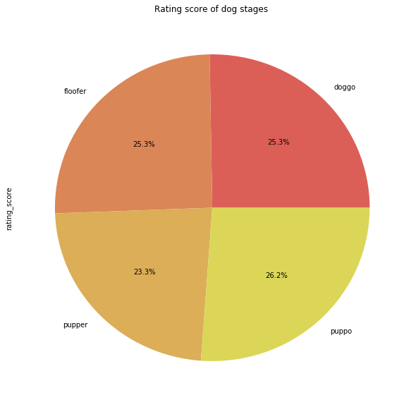

```python
#ploting pie chart that represent rating score of dog stages
from matplotlib import cm
import matplotlib.pyplot as plt
import seaborn as sns
%matplotlib inline
colors = sns.color_palette('hls', 20)
main_archive_df.groupby('Dog_stages').rating_score.mean().plot(kind='pie',figsize = (10,10),colors=colors,legend=False, autopct='%1.1f%%')
plt.title("Rating score of dog stages ")
```

```python
main_archive_df[main_archive_df.Dog_stages.notnull()]
```

|  | tweet_id | timestamp | source | tweet_content | retweeted_status_timestamp | expanded_urls | rating_numerator | rating_denominator | dog_name | jpg_url | ... | p2_dog | p3_conf | p3_dog | retweet_count | favorite_count | rating_score | Dog_stages | p1 | p2 | p3 |
| --- | --- | --- | --- | --- | --- | --- | --- | --- | --- | --- | --- | --- | --- | --- | --- | --- | --- | --- | --- | --- | --- |
| 9 | 890240255349198849 | 2017-07-26 15:59:51 | <a href="http://twitter.com/download/iphone" r... | This is Cassie. She is a college pup. Studying... | NaT | https://twitter.com/dog_rates/status/890240255... | 14.0 | 10.0 | Cassie | https://pbs.twimg.com/media/DFrEyVuW0AAO3t9.jpg | ... | True | 0.029248 | True | 7711.0 | 32467.0 | 1.4 | doggo | pembroke | cardigan | chihuahua |
| 12 | 889665388333682689 | 2017-07-25 01:55:32 | <a href="http://twitter.com/download/iphone" r... | Here's a puppo that seems to be on the fence a... | NaT | https://twitter.com/dog_rates/status/889665388... | 13.0 | 10.0 | no name | https://pbs.twimg.com/media/DFi579UWsAAatzw.jpg | ... | True | 0.004633 | True | 8538.0 | 38818.0 | 1.3 | puppo | pembroke | cardigan | basenji |
| 14 | 889531135344209921 | 2017-07-24 17:02:04 | <a href="http://twitter.com/download/iphone" r... | This is Stuart. He's sporting his favorite fan... | NaT | https://twitter.com/dog_rates/status/889531135... | 13.0 | 10.0 | Stuart | https://pbs.twimg.com/media/DFg_2PVW0AEHN3p.jpg | ... | True | 0.007958 | True | 2321.0 | 15359.0 | 1.3 | puppo | golden retriever | labrador retriever | redbone |
| 29 | 886366144734445568 | 2017-07-15 23:25:31 | <a href="http://twitter.com/download/iphone" r... | This is Roscoe. Another pupper fallen victim t... | NaT | https://twitter.com/dog_rates/status/886366144... | 12.0 | 10.0 | Roscoe | https://pbs.twimg.com/media/DE0BTnQUwAApKEH.jpg | ... | True | 0.000076 | True | 3316.0 | 21524.0 | 1.2 | pupper | french bulldog | chihuahua | boston bull |
| 43 | 884162670584377345 | 2017-07-09 21:29:42 | <a href="http://twitter.com/download/iphone" r... | Meet Yogi. He doesn't have any important dog m... | NaT | https://twitter.com/dog_rates/status/884162670... | 12.0 | 10.0 | Yogi | https://pbs.twimg.com/media/DEUtQbzW0AUTv_o.jpg | ... | True | 0.049148 | True | 3128.0 | 20771.0 | 1.2 | doggo | german shepherd | malinois | norwegian elkhound |
| 46 | 883360690899218434 | 2017-07-07 16:22:55 | <a href="http://twitter.com/download/iphone" r... | Meet Grizzwald. He may be the floofiest floofe... | NaT | https://twitter.com/dog_rates/status/883360690... | 13.0 | 10.0 | Grizzwald | https://pbs.twimg.com/media/DEJT3FeXoAAtwUy.jpg | ... | True | 0.002140 | True | 3825.0 | 22986.0 | 1.3 | floofer | chow | tibetan mastiff | newfoundland |
| 49 | 882762694511734784 | 2017-07-06 00:46:41 | <a href="http://twitter.com/download/iphone" r... | This is Gus. He's quite the cheeky pupper. Alr... | NaT | https://twitter.com/dog_rates/status/882762694... | 12.0 | 10.0 | Gus | https://pbs.twimg.com/media/DEAz_HHXsAA-p_z.jpg | ... | True | 0.015579 | True | 5134.0 | 28903.0 | 1.2 | pupper | labrador retriever | chesapeake bay retriever | flat-coated retriever |
| 56 | 881536004380872706 | 2017-07-02 15:32:16 | <a href="http://twitter.com/download/iphone" r... | Here is a pupper approaching maximum borkdrive... | NaT | https://twitter.com/dog_rates/status/881536004... | 14.0 | 10.0 | no name | https://pbs.twimg.com/ext_tw_video_thumb/88153... | ... | False | 0.114854 | False | 16570.0 | 50199.0 | 1.4 | pupper | samoyed | angora | persian cat |
| 71 | 878776093423087618 | 2017-06-25 00:45:22 | <a href="http://twitter.com/download/iphone" r... | This is Snoopy. He's a proud #PrideMonthPuppo.... | NaT | https://twitter.com/dog_rates/status/878776093... | 13.0 | 10.0 | Snoopy | https://pbs.twimg.com/media/DDIKMXzW0AEibje.jpg | ... | True | 0.039725 | True | 4319.0 | 19763.0 | 1.3 | puppo | italian greyhound | whippet | ibizan hound |
| 82 | 876838120628539392 | 2017-06-19 16:24:33 | <a href="http://twitter.com/download/iphone" r... | This is Ginger. She's having a ruff Monday. To... | NaT | https://twitter.com/dog_rates/status/876838120... | 12.0 | 10.0 | Ginger | https://pbs.twimg.com/media/DCsnnZsVwAEfkyi.jpg | ... | True | 0.088935 | True | 3506.0 | 21125.0 | 1.2 | pupper | bloodhound | redbone | tibetan mastiff |
| 92 | 874296783580663808 | 2017-06-12 16:06:11 | <a href="http://twitter.com/download/iphone" r... | This is Jed. He may be the fanciest pupper in ... | NaT | https://twitter.com/dog_rates/status/874296783... | 13.0 | 10.0 | Jed | https://pbs.twimg.com/media/DCIgSR0XgAANEOY.jpg | ... | True | 0.157402 | True | 4308.0 | 26651.0 | 1.3 | pupper | cocker spaniel | miniature poodle | toy poodle |
| 94 | 874012996292530176 | 2017-06-11 21:18:31 | <a href="http://twitter.com/download/iphone" r... | This is Sebastian. He can't see all the colors... | NaT | https://twitter.com/dog_rates/status/874012996... | 13.0 | 10.0 | Sebastian | https://pbs.twimg.com/media/DCEeLxjXsAAvNSM.jpg | ... | True | 0.049182 | True | 11007.0 | 35501.0 | 1.3 | puppo | cardigan | pembroke | kelpie |
| 98 | 873213775632977920 | 2017-06-09 16:22:42 | <a href="http://twitter.com/download/iphone" r... | This is Sierra. She's one precious pupper. Abs... | NaT | https://www.gofundme.com/help-my-baby-sierra-g... | 12.0 | 10.0 | Sierra | https://pbs.twimg.com/media/DB5HTBGXUAE0TiK.jpg | ... | True | 0.012676 | True | 1667.0 | 7467.0 | 1.2 | pupper | vizsla | bloodhound | chesapeake bay retriever |
| 99 | 872967104147763200 | 2017-06-09 00:02:31 | <a href="http://twitter.com/download/iphone" r... | Here's a very large dog. He has a date later. ... | NaT | https://twitter.com/dog_rates/status/872967104... | 12.0 | 10.0 | no name | https://pbs.twimg.com/media/DB1m871XUAAw5vZ.jpg | ... | True | 0.092861 | True | 5669.0 | 28031.0 | 1.2 | doggo | labrador retriever | chesapeake bay retriever | german short-haired pointer |
| 107 | 871762521631449091 | 2017-06-05 16:15:56 | <a href="http://twitter.com/download/iphone" r... | This is Rover. As part of pupper protocol he h... | NaT | https://twitter.com/dog_rates/status/871762521... | 12.0 | 10.0 | Rover | https://pbs.twimg.com/media/DBkfY58XcAEdzZy.jpg | ... | True | 0.003383 | True | 3678.0 | 20787.0 | 1.2 | pupper | labrador retriever | golden retriever | bloodhound |
| 108 | 871515927908634625 | 2017-06-04 23:56:03 | <a href="http://twitter.com/download/iphone" r... | This is Napolean. He's a Raggedy East Nicaragu... | NaT | https://twitter.com/dog_rates/status/871515927... | 12.0 | 10.0 | Napolean | https://pbs.twimg.com/media/DBg_HT9WAAEeIMM.jpg | ... | True | 0.003228 | False | 3628.0 | 20730.0 | 1.2 | doggo | komondor | briard | swab |
| 110 | 871102520638267392 | 2017-06-03 20:33:19 | <a href="http://twitter.com/download/iphone" r... | Never doubt a doggo 14/10 https://t.co/AbBLh2FZCH | NaT | https://twitter.com/animalcog/status/871075758... | 14.0 | 10.0 | no name | NaN | ... | NaN | NaN | NaN | 5764.0 | 21461.0 | 1.4 | doggo | NaN | NaN | NaN |
| 121 | 869596645499047938 | 2017-05-30 16:49:31 | <a href="http://twitter.com/download/iphone" r... | This is Scout. He just graduated. Officially a... | NaT | https://twitter.com/dog_rates/status/869596645... | 12.0 | 10.0 | Scout | https://pbs.twimg.com/media/DBFtiYqWAAAsjj1.jpg | ... | True | 0.006296 | False | 3327.0 | 16476.0 | 1.2 | doggo | chihuahua | toy terrier | muzzle |
| 129 | 867421006826221569 | 2017-05-24 16:44:18 | <a href="http://twitter.com/download/iphone" r... | This is Shikha. She just watched you drop a sk... | NaT | https://twitter.com/dog_rates/status/867421006... | 12.0 | 10.0 | Shikha | https://pbs.twimg.com/media/DAmyy8FXYAIH8Ty.jpg | ... | True | 0.001670 | True | 2697.0 | 16755.0 | 1.2 | puppo | eskimo dog | siberian husky | malamute |
| 135 | 866450705531457537 | 2017-05-22 00:28:40 | <a href="http://twitter.com/download/iphone" r... | This is Jamesy. He gives a kiss to every other... | NaT | https://twitter.com/dog_rates/status/866450705... | 13.0 | 10.0 | Jamesy | https://pbs.twimg.com/media/DAZAUfBXcAAG_Nn.jpg | ... | True | 0.001771 | True | 32883.0 | 106827.0 | 1.3 | pupper | french bulldog | boston bull | pug |
| 168 | 859607811541651456 | 2017-05-03 03:17:27 | <a href="http://twitter.com/download/iphone" r... | Sorry for the lack of posts today. I came home... | NaT | https://twitter.com/dog_rates/status/859607811... | 13.0 | 10.0 | no name | https://pbs.twimg.com/media/C-3wvtxXcAUTuBE.jpg | ... | True | 0.019285 | True | 1704.0 | 19476.0 | 1.3 | puppo | golden retriever | irish setter | labrador retriever |
| 172 | 858843525470990336 | 2017-05-01 00:40:27 | <a href="http://twitter.com/download/iphone" r... | I have stumbled puppon a doggo painting party.... | NaT | https://twitter.com/dog_rates/status/858843525... | 13.0 | 10.0 | no name | https://pbs.twimg.com/media/C-s5oYZXkAAMHHq.jpg | ... | True | 0.026917 | True | 3771.0 | 16304.0 | 1.3 | doggo | golden retriever | labrador retriever | bloodhound |
| 191 | 855851453814013952 | 2017-04-22 18:31:02 | <a href="http://twitter.com/download/iphone" r... | Here's a puppo participating in the #ScienceMa... | NaT | https://twitter.com/dog_rates/status/855851453... | 13.0 | 10.0 | no name | https://pbs.twimg.com/media/C-CYWrvWAAU8AXH.jpg | ... | True | 0.096100 | True | 19196.0 | 47844.0 | 1.3 | doggo | flat-coated retriever | labrador retriever | groenendael |
| 192 | 855851453814013952 | 2017-04-22 18:31:02 | <a href="http://twitter.com/download/iphone" r... | Here's a puppo participating in the #ScienceMa... | NaT | https://twitter.com/dog_rates/status/855851453... | 13.0 | 10.0 | no name | https://pbs.twimg.com/media/C-CYWrvWAAU8AXH.jpg | ... | True | 0.096100 | True | 19196.0 | 47844.0 | 1.3 | doggo | flat-coated retriever | labrador retriever | groenendael |
| 193 | 855851453814013952 | 2017-04-22 18:31:02 | <a href="http://twitter.com/download/iphone" r... | Here's a puppo participating in the #ScienceMa... | NaT | https://twitter.com/dog_rates/status/855851453... | 13.0 | 10.0 | no name | https://pbs.twimg.com/media/C-CYWrvWAAU8AXH.jpg | ... | True | 0.096100 | True | 19196.0 | 47844.0 | 1.3 | puppo | flat-coated retriever | labrador retriever | groenendael |
| 194 | 855851453814013952 | 2017-04-22 18:31:02 | <a href="http://twitter.com/download/iphone" r... | Here's a puppo participating in the #ScienceMa... | NaT | https://twitter.com/dog_rates/status/855851453... | 13.0 | 10.0 | no name | https://pbs.twimg.com/media/C-CYWrvWAAU8AXH.jpg | ... | True | 0.096100 | True | 19196.0 | 47844.0 | 1.3 | puppo | flat-coated retriever | labrador retriever | groenendael |
| 202 | 854120357044912130 | 2017-04-17 23:52:16 | <a href="http://twitter.com/download/iphone" r... | Sometimes you guys remind me just how impactfu... | NaT | https://twitter.com/dog_rates/status/854120357... | 14.0 | 10.0 | no name | https://pbs.twimg.com/media/C9px7jyVwAAnmwN.jpg | ... | True | 0.021762 | True | 8285.0 | 33911.0 | 1.4 | pupper | black-and-tan coonhound | doberman | bluetick |
| 203 | 854010172552949760 | 2017-04-17 16:34:26 | <a href="http://twitter.com/download/iphone" r... | At first I thought this was a shy doggo, but i... | NaT | https://twitter.com/dog_rates/status/854010172... | 11.0 | 10.0 | no name | https://pbs.twimg.com/media/C9oNt91WAAAFSLS.jpg | ... | True | 0.131706 | True | 3433.0 | 17169.0 | 1.1 | doggo | english springer | collie | border collie |
| 204 | 854010172552949760 | 2017-04-17 16:34:26 | <a href="http://twitter.com/download/iphone" r... | At first I thought this was a shy doggo, but i... | NaT | https://twitter.com/dog_rates/status/854010172... | 11.0 | 10.0 | no name | https://pbs.twimg.com/media/C9oNt91WAAAFSLS.jpg | ... | True | 0.131706 | True | 3433.0 | 17169.0 | 1.1 | doggo | english springer | collie | border collie |
| 205 | 854010172552949760 | 2017-04-17 16:34:26 | <a href="http://twitter.com/download/iphone" r... | At first I thought this was a shy doggo, but i... | NaT | https://twitter.com/dog_rates/status/854010172... | 11.0 | 10.0 | no name | https://pbs.twimg.com/media/C9oNt91WAAAFSLS.jpg | ... | True | 0.131706 | True | 3433.0 | 17169.0 | 1.1 | floofer | english springer | collie | border collie |
| ... | ... | ... | ... | ... | ... | ... | ... | ... | ... | ... | ... | ... | ... | ... | ... | ... | ... | ... | ... | ... | ... |
| 1917 | 675113801096802304 | 2015-12-11 00:44:07 | <a href="http://twitter.com/download/iphone" r... | Meet Zuzu. He just graduated college. Astute p... | NaT | https://twitter.com/dog_rates/status/675113801... | 10.0 | 10.0 | Zuzu | https://pbs.twimg.com/media/CV58a4nXAAApywo.jpg | ... | False | 0.043312 | False | 877.0 | 2120.0 | 1.0 | pupper | bow | quill | joystick |
| 1922 | 675006312288268288 | 2015-12-10 17:37:00 | <a href="http://twitter.com/download/iphone" r... | Say hello to Mollie. This pic was taken after ... | NaT | https://twitter.com/dog_rates/status/675006312... | 10.0 | 10.0 | Mollie | https://pbs.twimg.com/media/CV4aqCwWsAIi3OP.jpg | ... | False | 0.042848 | True | 252.0 | 1057.0 | 1.0 | pupper | boxer | space heater | beagle |
| 1931 | 674774481756377088 | 2015-12-10 02:15:47 | <a href="http://twitter.com/download/iphone" r... | This is Superpup. His head isn't proportional ... | NaT | https://twitter.com/dog_rates/status/674774481... | 11.0 | 10.0 | Superpup | https://pbs.twimg.com/media/CV1HztsWoAAuZwo.jpg | ... | True | 0.227677 | False | 532.0 | 1213.0 | 1.1 | pupper | chihuahua | french bulldog | siamese cat |
| 1939 | 674737130913071104 | 2015-12-09 23:47:22 | <a href="http://twitter.com/download/iphone" r... | Meet Rufio. He is unaware of the pink legless ... | NaT | https://twitter.com/dog_rates/status/674737130... | 10.0 | 10.0 | Rufio | https://pbs.twimg.com/media/CV0l10AU8AAfg-a.jpg | ... | True | 0.008120 | True | 103.0 | 693.0 | 1.0 | pupper | pomeranian | schipperke | chihuahua |
| 1945 | 674638615994089473 | 2015-12-09 17:15:54 | <a href="http://twitter.com/download/iphone" r... | This pupper is fed up with being tickled. 12/1... | NaT | https://twitter.com/dog_rates/status/674638615... | 12.0 | 10.0 | no name | https://pbs.twimg.com/media/CVzMPh1UsAELQ_p.jpg | ... | True | 0.002605 | True | 650.0 | 1806.0 | 1.2 | pupper | pomeranian | chow | keeshond |
| 1949 | 674447403907457024 | 2015-12-09 04:36:06 | <a href="http://twitter.com/download/iphone" r... | This pupper just wants a belly rub. This puppe... | NaT | https://twitter.com/dog_rates/status/674447403... | 10.0 | 10.0 | no name | https://pbs.twimg.com/media/CVweVUfW4AACPwI.jpg | ... | True | 0.074820 | True | 393.0 | 1137.0 | 1.0 | pupper | brabancon griffon | malinois | bull mastiff |
| 1957 | 674318007229923329 | 2015-12-08 20:01:55 | <a href="http://twitter.com/download/iphone" r... | This is Lennon. He's in quite the predicament.... | NaT | https://twitter.com/dog_rates/status/674318007... | 8.0 | 10.0 | Lennon | https://pbs.twimg.com/media/CVuopr8WwAExw_T.jpg | ... | False | 0.014680 | False | 570.0 | 1516.0 | 0.8 | pupper | porcupine | hamster | echidna |
| 1963 | 674262580978937856 | 2015-12-08 16:21:41 | <a href="http://twitter.com/download/iphone" r... | This is Gus. He's super stoked about being an ... | NaT | https://twitter.com/dog_rates/status/674262580... | 9.0 | 10.0 | Gus | https://pbs.twimg.com/media/CVt2PawWIAEUkqW.jpg | ... | True | 0.114498 | True | 498.0 | 1391.0 | 0.9 | pupper | greater swiss mountain dog | boxer | staffordshire bullterrier |
| 1972 | 674038233588723717 | 2015-12-08 01:30:12 | <a href="http://twitter.com/download/iphone" r... | This is Kaiya. She's an aspiring shoe model. 1... | NaT | https://twitter.com/dog_rates/status/674038233... | 12.0 | 10.0 | Kaiya | https://pbs.twimg.com/media/CVqqMtiVEAEye_L.jpg | ... | True | 0.148236 | True | 456.0 | 1176.0 | 1.2 | pupper | eskimo dog | norwegian elkhound | malamute |
| 1978 | 673956914389192708 | 2015-12-07 20:07:04 | <a href="http://twitter.com/download/iphone" r... | This is one esteemed pupper. Just graduated co... | NaT | https://twitter.com/dog_rates/status/673956914... | 10.0 | 10.0 | no name | https://pbs.twimg.com/media/CVpgPGwWoAEV7gG.jpg | ... | True | 0.045878 | True | 1069.0 | 2091.0 | 1.0 | pupper | pug | brabancon griffon | chihuahua |
| 1979 | 673919437611909120 | 2015-12-07 17:38:09 | <a href="http://twitter.com/download/iphone" r... | This is Obie. He is on guard watching for evil... | NaT | https://twitter.com/dog_rates/status/673919437... | 11.0 | 10.0 | Obie | https://pbs.twimg.com/media/CVo-JuMWwAAet6F.jpg | ... | True | 0.052175 | True | 401.0 | 1251.0 | 1.1 | pupper | jack-o'-lantern | schipperke | miniature pinscher |
| 1987 | 673707060090052608 | 2015-12-07 03:34:14 | <a href="http://twitter.com/download/iphone" r... | This is Raymond. He's absolutely terrified of ... | NaT | https://twitter.com/dog_rates/status/673707060... | 10.0 | 10.0 | Raymond | https://pbs.twimg.com/media/CVl8_EPWoAAcuSC.jpg | ... | True | 0.008847 | True | 434.0 | 1177.0 | 1.0 | pupper | german short-haired pointer | kelpie | labrador retriever |
| 1990 | 673697980713705472 | 2015-12-07 02:58:09 | <a href="http://twitter.com/download/iphone" r... | This is Pickles. She's a tiny pointy pupper. A... | NaT | https://twitter.com/dog_rates/status/673697980... | 8.0 | 10.0 | Pickles | https://pbs.twimg.com/media/CVl0vFeWoAAMTfg.jpg | ... | False | 0.058934 | False | 2165.0 | 4067.0 | 0.8 | pupper | porcupine | hen | doormat |
| 1996 | 673656262056419329 | 2015-12-07 00:12:23 | <a href="http://twitter.com/download/iphone" r... | This is Albert AKA King Banana Peel. He's a ki... | NaT | https://twitter.com/dog_rates/status/673656262... | 10.0 | 10.0 | Albert | https://pbs.twimg.com/media/CVlOy3pW4AQ9H1K.jpg | ... | True | 0.057559 | True | 265.0 | 769.0 | 1.0 | pupper | bull mastiff | rhodesian ridgeback | brabancon griffon |
| 1998 | 673612854080196609 | 2015-12-06 21:19:54 | <a href="http://twitter.com/download/iphone" r... | This is Jeffri. He's a speckled ice pupper. Ve... | NaT | https://twitter.com/dog_rates/status/673612854... | 7.0 | 10.0 | Jeffri | https://pbs.twimg.com/media/CVknUTlVEAARjU5.jpg | ... | True | 0.085626 | False | 802.0 | 1691.0 | 0.7 | pupper | newfoundland | leonberg | shovel |
| 2002 | 673363615379013632 | 2015-12-06 04:49:31 | <a href="http://twitter.com/download/iphone" r... | This little pupper can't wait for Christmas. H... | NaT | https://twitter.com/dog_rates/status/673363615... | 11.0 | 10.0 | no name | https://pbs.twimg.com/media/CVhEoq4WcAE8pBm.jpg | ... | False | 0.111177 | False | 338.0 | 1088.0 | 1.1 | pupper | ox | warthog | bison |
| 2009 | 673342308415348736 | 2015-12-06 03:24:51 | <a href="http://twitter.com/download/iphone" r... | This is Django. He's a skilled assassin pupper... | NaT | https://twitter.com/dog_rates/status/673342308... | 10.0 | 10.0 | Django | https://pbs.twimg.com/media/CVgxQc5XIAAYL0W.jpg | ... | True | 0.000652 | True | 649.0 | 1362.0 | 1.0 | pupper | ski mask | chihuahua | kelpie |
| 2012 | 673295268553605120 | 2015-12-06 00:17:55 | <a href="http://twitter.com/download/iphone" r... | Meet Eve. She's a raging alcoholic 8/10 (would... | NaT | https://twitter.com/dog_rates/status/673295268... | 8.0 | 10.0 | Eve | https://pbs.twimg.com/media/CVgGc9hWIAIe1bn.jpg | ... | True | 0.012613 | True | 3484.0 | 8046.0 | 0.8 | pupper | golden retriever | labrador retriever | great pyrenees |
| 2016 | 673148804208660480 | 2015-12-05 14:35:56 | <a href="http://twitter.com/download/iphone" r... | This is Fletcher. He's had a ruff night. No mo... | NaT | https://twitter.com/dog_rates/status/673148804... | 8.0 | 10.0 | Fletcher | https://pbs.twimg.com/media/CVeBQwiUsAAqhLw.jpg | ... | False | 0.025456 | False | 688.0 | 1822.0 | 0.8 | pupper | tub | bathtub | toilet seat |
| 2019 | 672988786805112832 | 2015-12-05 04:00:04 | <a href="http://twitter.com/download/iphone" r... | This is Schnozz. He's had a blurred tail since... | NaT | https://twitter.com/dog_rates/status/672988786... | 10.0 | 10.0 | Schnozz | https://pbs.twimg.com/media/CVbvjKqW4AA_CuD.jpg | ... | True | 0.038160 | True | 314.0 | 1039.0 | 1.0 | pupper | lakeland terrier | west highland white terrier | wire-haired fox terrier |
| 2022 | 672975131468300288 | 2015-12-05 03:05:49 | <a href="http://twitter.com/download/iphone" r... | This is Chuckles. He is one skeptical pupper. ... | NaT | https://twitter.com/dog_rates/status/672975131... | 10.0 | 10.0 | Chuckles | https://pbs.twimg.com/media/CVbjRSIWsAElw2s.jpg | ... | True | 0.036570 | True | 1015.0 | 1813.0 | 1.0 | pupper | pug | brabancon griffon | french bulldog |
| 2023 | 672970152493887488 | 2015-12-05 02:46:02 | <a href="http://twitter.com/download/iphone" r... | This is Chet. He's having a hard time. Really ... | NaT | https://twitter.com/dog_rates/status/672970152... | 7.0 | 10.0 | Chet | https://pbs.twimg.com/media/CVbeyGUU8AEq300.jpg | ... | False | 0.058034 | False | 391.0 | 1019.0 | 0.7 | pupper | leaf beetle | rhinoceros beetle | crayfish |
| 2027 | 672898206762672129 | 2015-12-04 22:00:08 | <a href="http://twitter.com/download/iphone" r... | This is Cheryl AKA Queen Pupper of the Skies. ... | NaT | https://twitter.com/dog_rates/status/672898206... | 11.0 | 10.0 | Cheryl | https://pbs.twimg.com/media/CVadWcCXIAAL4Sh.jpg | ... | False | 0.033079 | False | 459.0 | 944.0 | 1.1 | pupper | motor scooter | bobsled | moped |
| 2033 | 672622327801233409 | 2015-12-04 03:43:54 | <a href="http://twitter.com/download/iphone" r... | This lil pupper is sad because we haven't foun... | NaT | https://twitter.com/dog_rates/status/672622327... | 12.0 | 10.0 | no name | https://pbs.twimg.com/media/CVWicBbUYAIomjC.jpg | ... | True | 0.008786 | True | 542.0 | 1377.0 | 1.2 | pupper | golden retriever | labrador retriever | clumber |
| 2034 | 672614745925664768 | 2015-12-04 03:13:46 | <a href="http://twitter.com/download/iphone" r... | This is Norman. Doesn't bark much. Very docile... | NaT | https://twitter.com/dog_rates/status/672614745... | 6.0 | 10.0 | Norman | https://pbs.twimg.com/media/CVWbitUW4AAzclx.jpg | ... | False | 0.002015 | False | 644.0 | 1302.0 | 0.6 | pupper | starfish | goldfish | sea cucumber |
| 2037 | 672594978741354496 | 2015-12-04 01:55:13 | <a href="http://twitter.com/download/iphone" r... | Meet Scott. Just trying to catch his train to ... | NaT | https://twitter.com/dog_rates/status/672594978... | 9.0 | 10.0 | Scott | https://pbs.twimg.com/media/CVWJkJXWsAInlZl.jpg | ... | True | 0.027037 | True | 661.0 | 1411.0 | 0.9 | pupper | great pyrenees | old english sheepdog | afghan hound |
| 2044 | 672481316919734272 | 2015-12-03 18:23:34 | <a href="http://twitter.com/download/iphone" r... | Say hello to Jazz. She should be on the cover ... | NaT | https://twitter.com/dog_rates/status/672481316... | 12.0 | 10.0 | Jazz | https://pbs.twimg.com/media/CVUiMUeW4AEQgkU.jpg | ... | True | 0.094465 | True | 137.0 | 757.0 | 1.2 | pupper | border collie | collie | shetland sheepdog |
| 2051 | 672254177670729728 | 2015-12-03 03:21:00 | <a href="http://twitter.com/download/iphone" r... | This is Rolf. He's having the time of his life... | NaT | https://twitter.com/dog_rates/status/672254177... | 11.0 | 10.0 | Rolf | https://pbs.twimg.com/media/CVRTmz1WcAA4uMF.jpg | ... | True | 0.001618 | True | 800.0 | 1515.0 | 1.1 | pupper | pug | french bulldog | norwegian elkhound |
| 2057 | 672205392827572224 | 2015-12-03 00:07:09 | <a href="http://twitter.com/download/iphone" r... | This is Opal. He's a Royal John Coctostan. Rea... | NaT | https://twitter.com/dog_rates/status/672205392... | 9.0 | 10.0 | Opal | https://pbs.twimg.com/media/CVQnPMrVAAAzShR.jpg | ... | False | 0.003267 | True | 1270.0 | 2414.0 | 0.9 | pupper | carton | crate | pug |
| 2059 | 672160042234327040 | 2015-12-02 21:06:56 | <a href="http://twitter.com/download/iphone" r... | This is Bubba. He's a Titted Peebles Aorta. Ev... | NaT | https://twitter.com/dog_rates/status/672160042... | 8.0 | 10.0 | Bubba | https://pbs.twimg.com/media/CVP9_beUEAAwURR.jpg | ... | True | 0.065456 | True | 395.0 | 918.0 | 0.8 | pupper | pug | french bulldog | labrador retriever |

380 rows × 23 columns

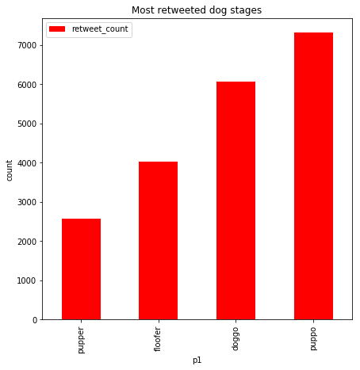

```python
#plot of bar chart of dog stages based on retweet count
main_archive_df.groupby('Dog_stages').retweet_count.mean().sort_values().plot(kind='bar',figsize = (7,7), color='red')
plt.xlabel('p1')
plt.ylabel('count')
plt.title("Most retweeted dog stages")
plt.legend()
```

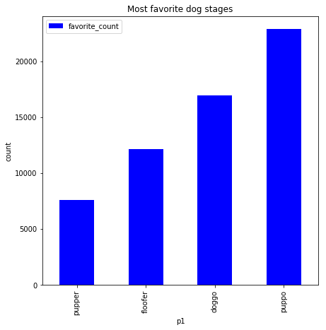

```python
#plot of bar chart of dog stages based on favorite count
main_archive_df.groupby('Dog_stages').favorite_count.mean().sort_values().plot(kind='bar',figsize = (7,7), color='blue')
plt.xlabel('p1')
plt.ylabel('count')
plt.title("Most favorite dog stages")
plt.legend()
```

```python
# Sort the DataFrame in descending order; will create a Series
s_temp = main_archive_df.p1.value_counts().sort_values(ascending=False)
# Count how many rows are not in the top ten
not_top_ten = len(s_temp) - 15
# Sum the values not in the top ten
not_top_ten_sum = s_temp.tail(not_top_ten).sum()
# Get the top ten values
s_top = s_temp.head(15)
# Append the sum of not-top-ten values to the Series
s_top[14] = not_top_ten_sum
df = pd.DataFrame(s_top)
df = df.reset_index(level=0)
df.rename(columns = {'index':'p1', 'p1':'counts'}, inplace = True)
df.p1=df.p1.replace("flat-coated retriever", "others", regex=True)
```

```
Text(0.5,1,'counts of p1 predictions of dog')
```

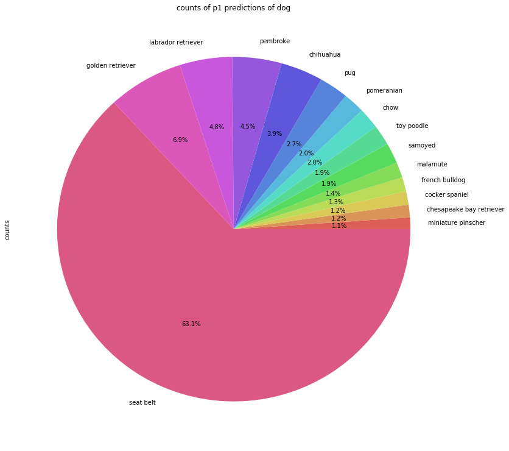

```python
#pie chart plot of counts of p1 predictions of dog names
colors = sns.color_palette('hls', 15)
df.groupby('p1').counts.mean().sort_values().plot(kind='pie',figsize = (13,13),colors=colors,legend=False, autopct='%1.1f%%')
plt.title("counts of p1 predictions of dog")
#plt.legend()
```

```python
main_archive_df.p1.value_counts()
```

```
golden retriever             134
labrador retriever            93
pembroke                      87
chihuahua                     75
pug                           52
chow                          38
pomeranian                    38
samoyed                       37
toy poodle                    37
malamute                      28
french bulldog                26
cocker spaniel                24
chesapeake bay retriever      23
miniature pinscher            21
seat belt                     20
siberian husky                20
german shepherd               20
staffordshire bullterrier     18
maltese dog                   18
teddy                         18
eskimo dog                    18
shetland sheepdog             18
rottweiler                    17
shih-tzu                      17
dalmatian                     17
beagle                        16
italian greyhound             16
kuvasz                        16
web site                      15
lakeland terrier              15
                            ...
electric fan                   1
lawn mower                     1
limousine                      1
dishwasher                     1
ocarina                        1
bow                            1
fire engine                    1
timber wolf                    1
bakery                         1
boathouse                      1
radio telescope                1
scorpion                       1
remote control                 1
cheeseburger                   1
entlebucher                    1
pot                            1
japanese spaniel               1
bighorn                        1
cowboy boot                    1
four-poster                    1
african hunting dog            1
hare                           1
banana                         1
black-footed ferret            1
bearskin                       1
loupe                          1
nail                           1
marmot                         1
prison                         1
leaf beetle                    1
Name: p1, Length: 369, dtype: int64
```

```python
main_archive_df.query('p1=="golden retriever"').favorite_count.mean()
```

```
11366.664179104477
```

```python
main_archive_df.query('p1=="golden retriever"').retweet_count.mean()
```

```
3262.0597014925374
```

```python
main_archive_df.query('p1=="golden retriever"').rating_score.mean()
```

```
1.1584921328358209
```

```python
main_archive_df.query('p1=="labrador retriever"').favorite_count.mean()
```

```
10478.569892473119
```

```python
main_archive_df.query('p1=="labrador retriever"').retweet_count.mean()
```

```
3341.2903225806454
```

```python
main_archive_df.query('p1=="labrador retriever"').rating_score.mean()
```

```
1.1186875892473116
```

Ref regarding visualization section https://stackoverflow.com/questions/29219055/plot-top-10-verse-all-other-values